# Analysis of contextualized sensorimotor norms

Sean Trott

January 19, 2026

# Introduction

In this document, we analyze the **contextualized sensorimotor norms**: judgments about the strength of different sensorimotor dimensions of ambiguous words, in context.

We use these norms in several analyses:

1. First, we compare them to the corresponding dimensions for the “decontextualized” Lancaster sensorimotor norms.
2. Second, we ask whether the **dominance** of a word sense is correlated with its sensorimotor strength, i.e., whether more concrete meanings tend to be rated as more dominant.
3. Third, we ask whether the **sensorimotor distance** between two contexts of use predicts judgments of how **related** those meanings are, above and beyond their distributional similarity and whether or not they belong to the same sense.
4. Fourth, we use **sensorimotor distance** to predict behavior on a primed sensibility judgment task.

# Characterizing dimensions

First, load the data.

```r
# setwd("/Users/seantrott/Dropbox/UCSD/Research/Ambiguity/SSD/cs_norms/src/analysis")
df_contextualized_meanings = read_csv("../../data/processed/contextualized_sensorimotor_norms.csv")
```

```
## ──────────────────────────────────────────────────────── Delimiter: "," chr
## (3): word, sentence, context dbl (25): ...1, Vision.M, Vision.SD, Hearing.M,
## Hearing.SD, Olfaction.M, Olf...
```

```r
nrow(df_contextualized_meanings)
```

```
## [1] 448
```

## Visualizing distributions

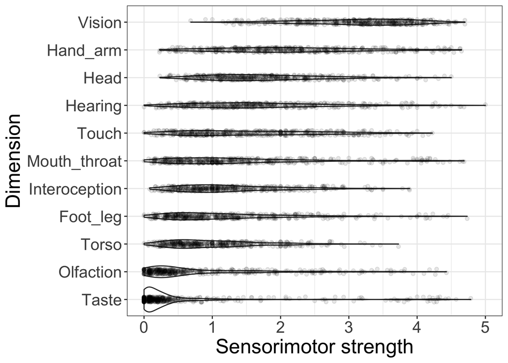

```r
df_contextualized_meanings_long = df_contextualized_meanings %>%
  pivot_longer(cols = c(Vision.M, Hearing.M, Olfaction.M,
                        Taste.M, Interoception.M, Touch.M,
                        Mouth_throat.M, Head.M, Torso.M,
                        Hand_arm.M, Foot_leg.M),
               names_to = "Dimension",
               values_to = "Strength") %>%
  mutate(Dimension = gsub('.M', '', Dimension))

df_contextualized_meanings_long %>%
  ggplot(aes(x = reorder(Dimension, Strength),
             y = Strength)) +
  geom_violin() +
  geom_jitter(alpha = .1,
              width = .1) +
  coord_flip() +
  labs(y = "Sensorimotor strength",
       x = "Dimension") +
  theme_bw() +
  theme(text = element_text(size=20))
```

## Correlations across dimensions

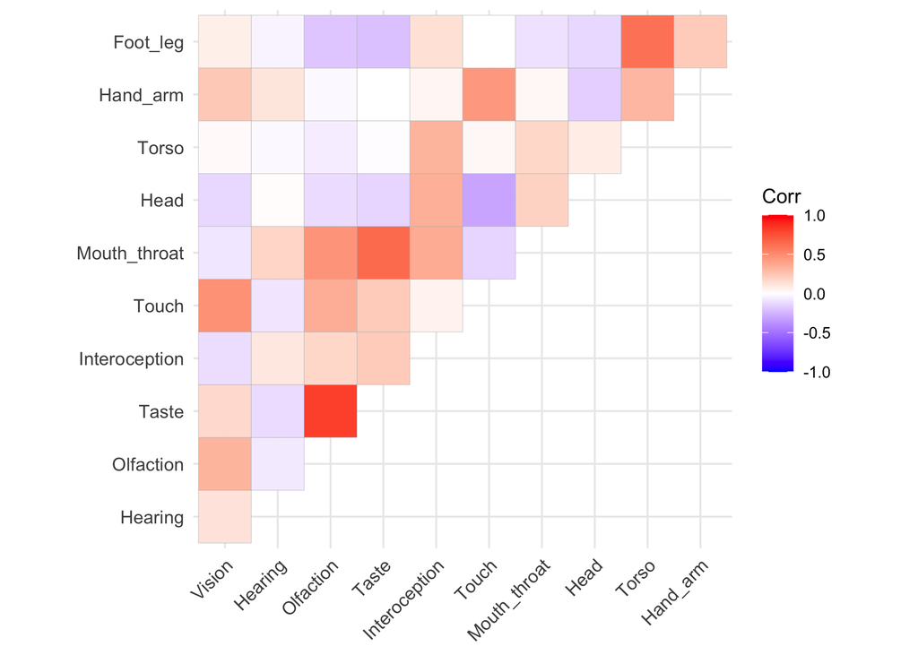

```r
columns = df_contextualized_meanings %>%
  mutate(Vision = Vision.M,
         Hearing = Hearing.M,
         Olfaction = Olfaction.M,
         Taste = Taste.M,
         Interoception = Interoception.M,
         Touch = Touch.M,
         Mouth_throat = Mouth_throat.M,
         Head = Head.M,
         Torso = Torso.M,
         Hand_arm = Hand_arm.M,
         Foot_leg = Foot_leg.M) %>%
  select(Vision, Hearing, Olfaction,
         Taste, Interoception, Touch,
         Mouth_throat, Head, Torso,
         Hand_arm, Foot_leg)
cors = cor(columns)

# cors[lower.tri(cors, diag=TRUE)] <- 0


# Plot the correlation matrix
ggcorrplot(cors,
           hc.order = FALSE,
           # method = "square",
           type = "upper") +
  theme(
    axis.text.x = element_text(size = 10, angle = 45, hjust = 1),
    axis.text.y = element_text(size = 10)
  )
```

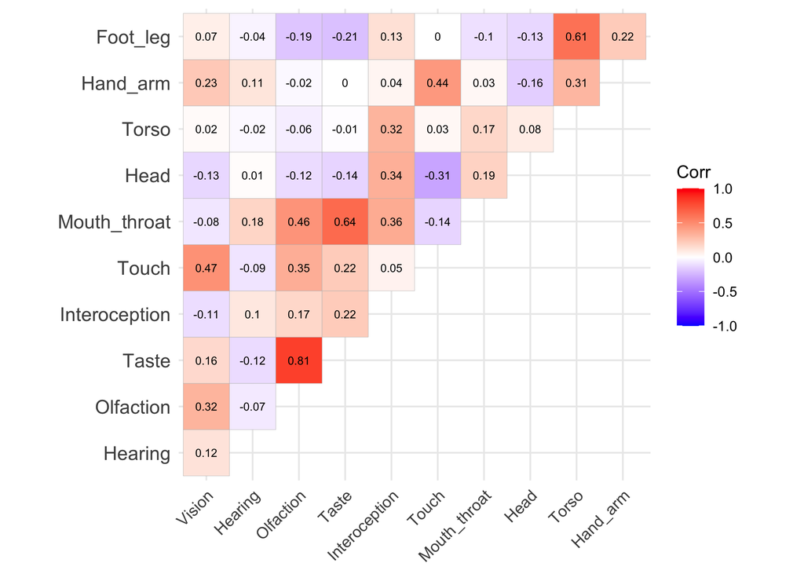

```r
ggcorrplot(cors, hc.order = FALSE, type = "upper",
                      lab = TRUE, lab_size = 2.5) +
  theme(axis.text.x = element_text(size = 10, angle = 45, hjust = 1))
```

# Predicting dominance

## Load and merge data

Load the item-level means for the sensorimotor norms.

```r
df_contextualized_meanings = read_csv("../../data/processed/contextualized_sensorimotor_norms_with_ls.csv")
```

```
## ──────────────────────────────────────────────────────── Delimiter: "," chr
## (3): word, sentence, context dbl (27): ...1, Unnamed: 0, Vision.M, Vision.SD,
## Hearing.M, Hearing.SD, Olfa...
```

```r
nrow(df_contextualized_meanings)
```

```
## [1] 448
```

Load the dominance norms.

```r
df_dominance = read_csv("../../data/processed/dominance_norms_with_order.csv")
```

```
## ──────────────────────────────────────────────────────── Delimiter: "," chr
## (3): word, version_with_order, ambiguity_type dbl (3): ...1, dominance_right,
## sd_dominance
```

```r
## Determine the specific sense/meaning of the righthand context
df_dominance = df_dominance %>%
  mutate(context = substr(version_with_order, 6, 9))

## Now group by that righthand context to get relative dominance of that meaning
df_dominance_individual = df_dominance %>%
  group_by(word, context) %>%
  summarise(dominance = mean(dominance_right))
nrow(df_dominance_individual)
```

```
## [1] 448
```

Merge the dominance and sensorimotor norms data.

```r
df_dom_plus_sm = df_contextualized_meanings %>%
  inner_join(df_dominance_individual)
nrow(df_dom_plus_sm)
```

```
## [1] 448
```

We also load and merge the Lancaster norms, as a control.

```r
df_lancaster <- read_csv("../../data/lexical/lancaster_norms.csv") %>%
  mutate(word = tolower(Word)) %>%
  rename(
    Foot_leg.SD.LS = Foot_leg.SD,
    Hand_arm.SD.LS = Hand_arm.SD,
    Head.SD.LS = Head.SD,
    Torso.SD.LS = Torso.SD
  )
df_dom_plus_sm <- df_dom_plus_sm %>%
  inner_join(df_lancaster)
nrow(df_dom_plus_sm)
```

```
## [1] 448
```

## Calculating contextualized sensorimotor strength

Based on Lynott et al (2019), we **contextualized sensorimotor strength** as the *maximum* strength across all the dimensions.

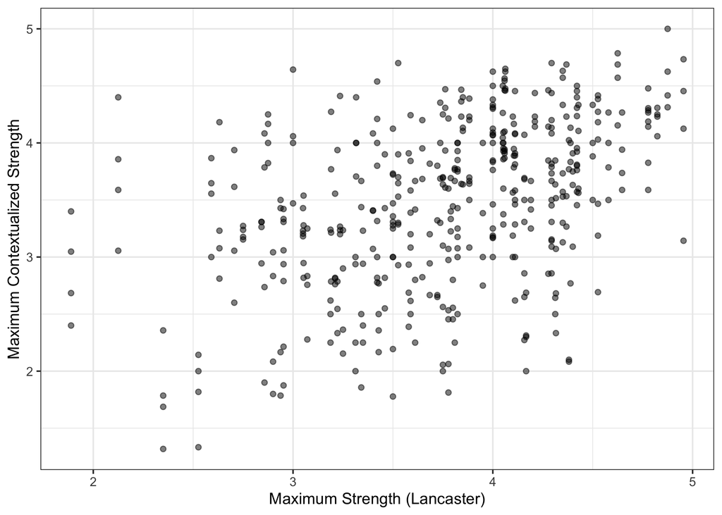

```r
df_dom_plus_sm = df_dom_plus_sm %>%
  rowwise() %>%
  mutate(max_strength = max(
    c(
      ## Modalities
      Vision.M,
      Hearing.M,
      Olfaction.M,
      Touch.M,
      Taste.M,
      Interoception.M,
      ## Effectors
      Head.M,
      Mouth_throat.M,
      Torso.M,
      Hand_arm.M,
      Foot_leg.M
    )
  ),
  minkowski3_strength = sum(c(Vision.M, Hearing.M, Olfaction.M, Touch.M, Taste.M,
                               Interoception.M, Head.M, Mouth_throat.M, Torso.M,
                               Hand_arm.M, Foot_leg.M)^3)^(1/3),
  max_perceptual_strength = max(
    c(
      ## Modalities
      Vision.M,
      Hearing.M,
      Olfaction.M,
      Touch.M,
      Taste.M,
      Interoception.M
    )
  ),
  max_action_strength = max(
    c(
      ## Effectors
      Head.M,
      Mouth_throat.M,
      Torso.M,
      Hand_arm.M,
      Foot_leg.M
    )
  )
  ) %>%
  ungroup()

df_dom_plus_sm %>%
  ggplot(aes(x = Max_strength.sensorimotor,
             y = max_strength)) +
  geom_point(alpha = .5) +
  labs(y = "Maximum Contextualized Strength",
       x = "Maximum Strength (Lancaster)") +
  theme_bw()
```

```r
cor.test(df_dom_plus_sm$Max_strength.sensorimotor,
         df_dom_plus_sm$max_strength)
```

```
##
##  Pearson's product-moment correlation
##
## data:  df_dom_plus_sm$Max_strength.sensorimotor and df_dom_plus_sm$max_strength
## t = 10.373, df = 446, p-value < 2.2e-16
## alternative hypothesis: true correlation is not equal to 0
## 95 percent confidence interval:
##  0.3630485 0.5125743
## sample estimates:
##      cor
## 0.440865
```

```r
cor.test(df_dom_plus_sm$max_strength,
         df_dom_plus_sm$minkowski3_strength)
```

```
##
##  Pearson's product-moment correlation
##
## data:  df_dom_plus_sm$max_strength and df_dom_plus_sm$minkowski3_strength
## t = 38.105, df = 446, p-value < 2.2e-16
## alternative hypothesis: true correlation is not equal to 0
## 95 percent confidence interval:
##  0.8509620 0.8947899
## sample estimates:
##       cor
## 0.8746517
```

## Does contextualized sensorimotor strength predict dominance?

The answer is **yes**: contexts with a higher *maximum* sensorimotor strength also tend to be rated as more *dominant*.

Notably, this is true above and beyond the *decontextualized* ratings of sensorimotor strength for a given word.

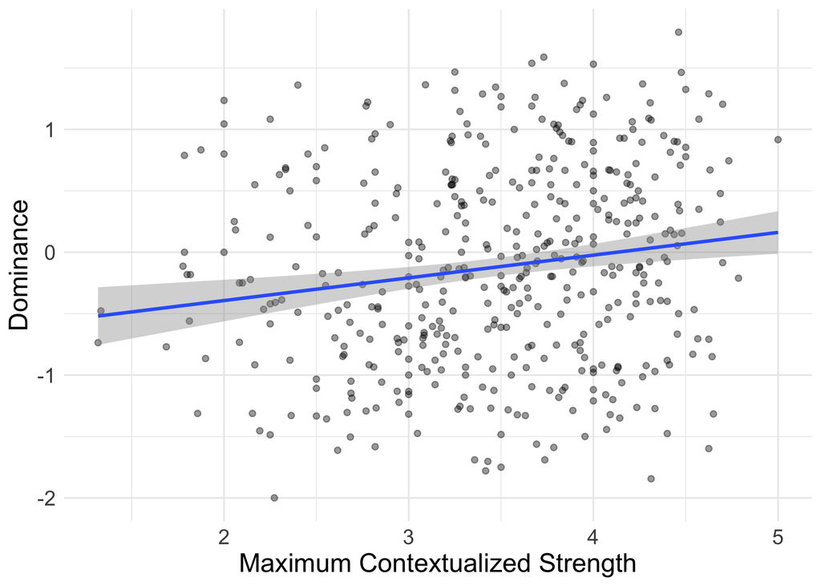

```r
df_dom_plus_sm %>%
  ggplot(aes(x = max_strength,
             y = dominance)) +
  geom_point(alpha = .4) +
  geom_smooth(method = "lm") +
  labs(x = "Maximum Contextualized Strength",
       y = "Dominance") +
  theme_minimal() +
  theme(text = element_text(size=16))
```

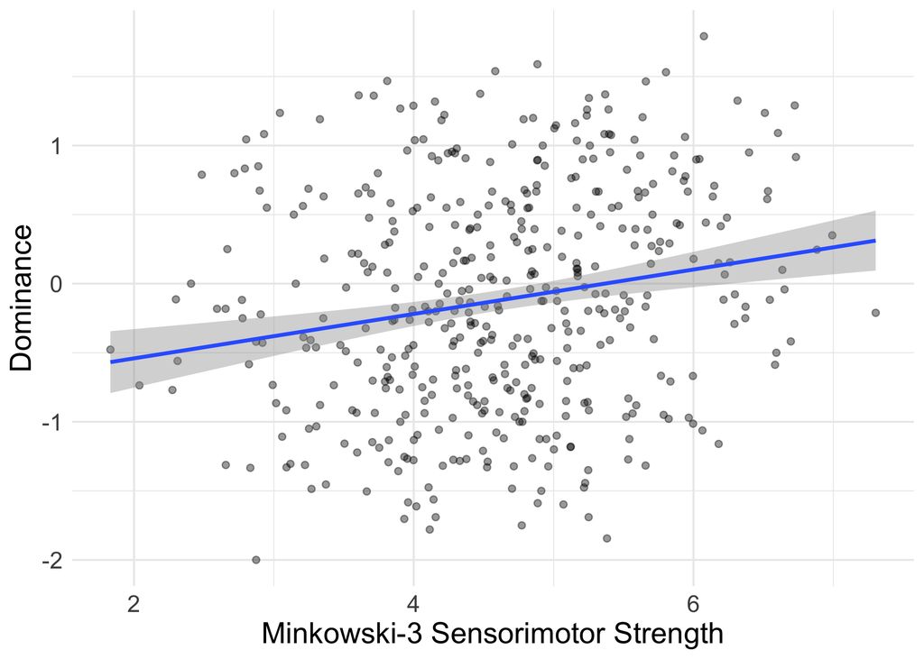

```r
df_dom_plus_sm %>%
  ggplot(aes(x = minkowski3_strength,
             y = dominance)) +
  geom_point(alpha = .4) +
  geom_smooth(method = "lm") +
  labs(x = "Minkowski-3 Sensorimotor Strength",
       y = "Dominance") +
  theme_minimal() +
  theme(text = element_text(size=16))
```

```r
model_full = lmer(data = df_dom_plus_sm,
                dominance ~
                  max_strength +
                  Max_strength.sensorimotor + Minkowski3.sensorimotor +
                  (1 | word),
                REML = FALSE)
```

```
## boundary (singular) fit: see help('isSingular')
```

```r
model_reduced = lmer(data = df_dom_plus_sm,
                dominance ~
                  # max_strength +
                  Max_strength.sensorimotor + Minkowski3.sensorimotor +
                  (1 | word),
                REML = FALSE)
```

```
## boundary (singular) fit: see help('isSingular')
```

```r
summary(model_full)
```

```
## Linear mixed model fit by maximum likelihood . t-tests use Satterthwaite's
##   method [lmerModLmerTest]
## Formula:
## dominance ~ max_strength + Max_strength.sensorimotor + Minkowski3.sensorimotor +
##     (1 | word)
##    Data: df_dom_plus_sm
##
##       AIC       BIC    logLik -2*log(L)  df.resid
##    1070.7    1095.3    -529.4    1058.7       442
##
## Scaled residuals:
##      Min       1Q   Median       3Q      Max
## -2.30770 -0.76937 -0.01941  0.78910  2.13757
##
## Random effects:
##  Groups   Name        Variance Std.Dev.
##  word     (Intercept) 0.0000   0.0000
##  Residual             0.6221   0.7887
## Number of obs: 448, groups:  word, 112
##
## Fixed effects:
##                            Estimate Std. Error        df t value Pr(>|t|)
## (Intercept)                -0.47619    0.24549 448.00000  -1.940   0.0530 .
## max_strength                0.25833    0.05964 448.00000   4.332 1.83e-05 ***
## Max_strength.sensorimotor   0.02905    0.10851 448.00000   0.268   0.7891
## Minkowski3.sensorimotor    -0.13254    0.07421 448.00000  -1.786   0.0748 .
## ---
## Signif. codes:  0 '***' 0.001 '**' 0.01 '*' 0.05 '.' 0.1 ' ' 1
##
## Correlation of Fixed Effects:
##             (Intr) mx_str Mx_st.
## max_strngth -0.366
## Mx_strngth. -0.430 -0.070
## Mnkwsk3.sns  0.032 -0.244 -0.789
## optimizer (nloptwrap) convergence code: 0 (OK)
## boundary (singular) fit: see help('isSingular')
```

```r
anova(model_full, model_reduced)
```

```
## Data: df_dom_plus_sm
## Models:
## model_reduced: dominance ~ Max_strength.sensorimotor + Minkowski3.sensorimotor + (1 | word)
## model_full: dominance ~ max_strength + Max_strength.sensorimotor + Minkowski3.sensorimotor + (1 | word)
##               npar    AIC    BIC  logLik -2*log(L)  Chisq Df Pr(>Chisq)
## model_reduced    5 1087.1 1107.6 -538.54    1077.1
## model_full       6 1070.7 1095.3 -529.35    1058.7 18.381  1  1.808e-05 ***
## ---
## Signif. codes:  0 '***' 0.001 '**' 0.01 '*' 0.05 '.' 0.1 ' ' 1
```

```r
model_full = lmer(data = df_dom_plus_sm,
                dominance ~
                  minkowski3_strength +
                  Max_strength.sensorimotor + Minkowski3.sensorimotor +
                  (1 | word),
                REML = FALSE)
```

```
## boundary (singular) fit: see help('isSingular')
```

```r
model_reduced = lmer(data = df_dom_plus_sm,
                dominance ~
                  # max_strength +
                  Max_strength.sensorimotor + Minkowski3.sensorimotor +
                  (1 | word),
                REML = FALSE)
```

```
## boundary (singular) fit: see help('isSingular')
```

```r
summary(model_full)
```

```
## Linear mixed model fit by maximum likelihood . t-tests use Satterthwaite's
##   method [lmerModLmerTest]
## Formula: dominance ~ minkowski3_strength + Max_strength.sensorimotor +
##     Minkowski3.sensorimotor + (1 | word)
##    Data: df_dom_plus_sm
##
##       AIC       BIC    logLik -2*log(L)  df.resid
##    1056.8    1081.4    -522.4    1044.8       442
##
## Scaled residuals:
##      Min       1Q   Median       3Q      Max
## -2.29817 -0.78840 -0.00244  0.74420  2.31144
##
## Random effects:
##  Groups   Name        Variance Std.Dev.
##  word     (Intercept) 0.000    0.0000
##  Residual             0.603    0.7765
## Number of obs: 448, groups:  word, 112
##
## Fixed effects:
##                            Estimate Std. Error        df t value Pr(>|t|)
## (Intercept)                -0.60579    0.24212 448.00000  -2.502 0.012706 *
## minkowski3_strength         0.27582    0.04764 448.00000   5.789 1.33e-08 ***
## Max_strength.sensorimotor   0.14156    0.10746 448.00000   1.317 0.188405
## Minkowski3.sensorimotor    -0.26854    0.07996 448.00000  -3.358 0.000851 ***
## ---
## Signif. codes:  0 '***' 0.001 '**' 0.01 '*' 0.05 '.' 0.1 ' ' 1
##
## Correlation of Fixed Effects:
##             (Intr) mnkw3_ Mx_st.
## mnkwsk3_str -0.370
## Mx_strngth. -0.500  0.128
## Mnkwsk3.sns  0.119 -0.464 -0.792
## optimizer (nloptwrap) convergence code: 0 (OK)
## boundary (singular) fit: see help('isSingular')
```

```r
anova(model_full, model_reduced)
```

```
## Data: df_dom_plus_sm
## Models:
## model_reduced: dominance ~ Max_strength.sensorimotor + Minkowski3.sensorimotor + (1 | word)
## model_full: dominance ~ minkowski3_strength + Max_strength.sensorimotor + Minkowski3.sensorimotor + (1 | word)
##               npar    AIC    BIC  logLik -2*log(L)  Chisq Df Pr(>Chisq)
## model_reduced    5 1087.1 1107.6 -538.54    1077.1
## model_full       6 1056.8 1081.4 -522.38    1044.8 32.323  1  1.306e-08 ***
## ---
## Signif. codes:  0 '***' 0.001 '**' 0.01 '*' 0.05 '.' 0.1 ' ' 1
```

### Examples

```r
### Top 10
df_dom_plus_sm %>%
  arrange(desc(minkowski3_strength)) %>%
  select(word, sentence, minkowski3_strength, dominance) %>%
  head(10)
```

```
## # A tibble: 10 × 4
##    word      sentence                         minkowski3_strength dominance
##    <chr>     <chr>                                          <dbl>     <dbl>
##  1 breakfast They ate a pancake breakfast.                   7.30   -0.211
##  2 breakfast They ate a family breakfast.                    6.99    0.35
##  3 breakfast They ate a nutritious breakfast.                6.88    0.246
##  4 sing      The choir sang.                                 6.73    0.917
##  5 medicine  It was cough medicine.                          6.72    1.29
##  6 dinner    They liked the turkey dinner.                   6.70   -0.418
##  7 movement  He liked the rhythmic movement.                 6.65   -0.0417
##  8 dinner    They liked the light dinner.                    6.64    0.1
##  9 chicken   They liked the roasted chicken.                 6.60    1.09
## 10 orange    It was a juicy orange.                          6.59   -0.5
```

```r
### Bottom 10
df_dom_plus_sm %>%
  arrange(minkowski3_strength) %>%
  select(word, sentence, minkowski3_strength, dominance) %>%
  head(10)
```

```
## # A tibble: 10 × 4
##    word       sentence                          minkowski3_strength dominance
##    <chr>      <chr>                                           <dbl>     <dbl>
##  1 cause      It was a main cause.                             1.83    -0.477
##  2 term       It was a winter term.                            2.04    -0.736
##  3 term       It was a fall term.                              2.27    -0.770
##  4 foundation It was an educational foundation.                2.30    -0.114
##  5 date       It was a historical date.                        2.31    -0.560
##  6 term       It was a legal term.                             2.41     0
##  7 case       It was a criminal case.                          2.48     0.789
##  8 cause      It was a political cause.                        2.59    -0.182
##  9 appeal     He had a legal appeal.                           2.65    -0.182
## 10 drain      They drained the budget.                         2.66    -1.31
```

```r
### Top 10
df_dom_plus_sm %>%
  arrange(desc(max_strength)) %>%
  select(word, sentence, max_strength, dominance) %>%
  head(10)
```

```
## # A tibble: 10 × 4
##    word      sentence                         max_strength dominance
##    <chr>     <chr>                                   <dbl>     <dbl>
##  1 sing      The choir sang.                          5       0.917
##  2 breakfast They ate a pancake breakfast.            4.79   -0.211
##  3 run       She ran the marathon.                    4.73    0.745
##  4 newspaper It was a national newspaper.             4.7    -0.0848
##  5 track     She saw the train tracks.                4.7     1.21
##  6 band      It was a jazz band.                      4.69    0.478
##  7 breakfast They ate a nutritious breakfast.         4.69    0.246
##  8 draw      He drew a sword.                         4.65   -1.32
##  9 racket    That was a loud racket.                  4.64   -0.85
## 10 punch     He had the quickest punch.               4.63    0.670
```

```r
### Bottom 10
df_dom_plus_sm %>%
  arrange(max_strength) %>%
  select(word, sentence, max_strength, dominance) %>%
  head(10)
```

```
## # A tibble: 10 × 4
##    word       sentence                          max_strength dominance
##    <chr>      <chr>                                    <dbl>     <dbl>
##  1 term       It was a winter term.                     1.32    -0.736
##  2 cause      It was a main cause.                      1.33    -0.477
##  3 term       It was a fall term.                       1.69    -0.770
##  4 foundation It was an educational foundation.         1.78    -0.114
##  5 case       It was a criminal case.                   1.79     0.789
##  6 term       It was a legal term.                      1.79     0
##  7 appeal     He had a legal appeal.                    1.8     -0.182
##  8 date       It was a historical date.                 1.81    -0.560
##  9 cause      It was a political cause.                 1.82    -0.182
## 10 drain      They drained the budget.                  1.86    -1.31
```

### Which dimension best predicts dominance?

Here, we ask whether specific dimensions are particularly correlated with sense dominance.

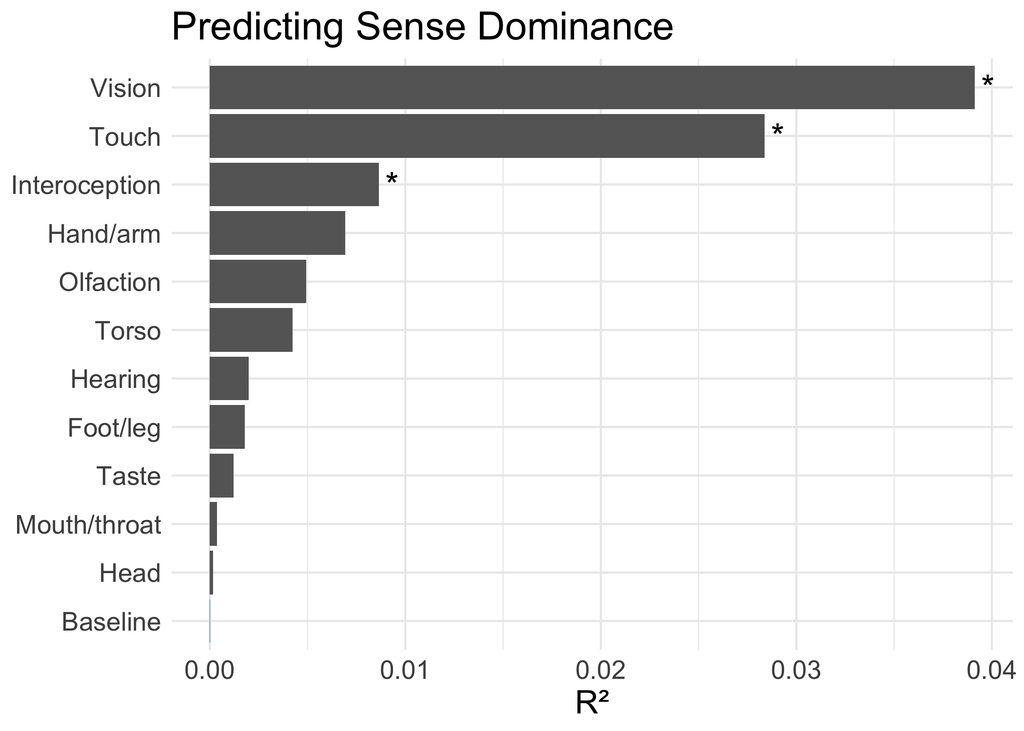

```r
features <- c("Vision.M", "Hearing.M", "Olfaction.M", "Touch.M", "Taste.M",
              "Interoception.M", "Head.M", "Mouth_throat.M", "Torso.M",
              "Hand_arm.M", "Foot_leg.M")

# Models with each feature + baseline covariate
r2_results <- map_dfr(features, function(feat) {

  formula <- as.formula(paste0("dominance ~ Max_strength.sensorimotor + ", feat))
  model <- lm(formula, data = df_dom_plus_sm)

  tibble(
    feature = feat,
    R2 = summary(model)$r.squared,
    beta = coef(model)[3],  # coefficient for the feature (3rd term now)
    p_value = summary(model)$coefficients[3, 4]
  )
})

# Baseline model (just Max_strength.sensorimotor)
baseline_model <- lm(dominance ~ Max_strength.sensorimotor, data = df_dom_plus_sm)

baseline_row <- tibble(
  feature = "Baseline",
  R2 = summary(baseline_model)$r.squared,
  beta = NA,
  p_value = NA
)

# Combine
r2_results_with_baseline <- bind_rows(baseline_row, r2_results)

# Plot
r2_results_with_baseline %>%
  mutate(feature = str_remove(feature, "\\.M$"),
         feature = str_replace(feature, "_", "/"),
         sig = ifelse(p_value < .05, "*", ""),
         is_baseline = feature == "Baseline",
         feature = fct_reorder(feature, R2)) %>%
  ggplot(aes(x = R2, y = feature, fill = is_baseline)) +
  geom_col() +
  geom_text(aes(label = sig), hjust = -0.5, size = 6, na.rm = TRUE) +
  scale_fill_manual(values = c("grey40", "steelblue"), guide = "none") +
  labs(x = "R²", y = NULL, title = "Predicting Sense Dominance") +
  theme_minimal() +
  theme(text = element_text(size = 16))
```

```r
cor.test(df_dom_plus_sm$Touch.M,
         df_dom_plus_sm$dominance)
```

```
##
##  Pearson's product-moment correlation
##
## data:  df_dom_plus_sm$Touch.M and df_dom_plus_sm$dominance
## t = 3.5374, df = 446, p-value = 0.0004464
## alternative hypothesis: true correlation is not equal to 0
## 95 percent confidence interval:
##  0.07368382 0.25395880
## sample estimates:
##       cor
## 0.1652009
```

```r
cor.test(df_dom_plus_sm$Vision.M,
         df_dom_plus_sm$dominance)
```

```
##
##  Pearson's product-moment correlation
##
## data:  df_dom_plus_sm$Vision.M and df_dom_plus_sm$dominance
## t = 4.0423, df = 446, p-value = 6.235e-05
## alternative hypothesis: true correlation is not equal to 0
## 95 percent confidence interval:
##  0.09703963 0.27583493
## sample estimates:
##       cor
## 0.1879943
```

It looks like vision and touch are especially strong predictors. Which items drive this, e.g., for touch?

```r
by_sense <- df_dom_plus_sm %>%
  mutate(sense = str_extract(context, "M[12]")) %>%
  group_by(word, sense) %>%
  summarize(
    mean_touch = mean(Touch.M),
    mean_vision = mean(Vision.M),
    mean_dom = mean(dominance),
    .groups = "drop"
  )

# Now 2 rows per word—compute within-word difference
sense_diffs <- by_sense %>%
  pivot_wider(names_from = sense,
              values_from = c(mean_touch, mean_vision, mean_dom)) %>%
  mutate(
    touch_diff = mean_touch_M1 - mean_touch_M2,
    vision_diff = mean_vision_M1 - mean_vision_M2,
    dom_diff = mean_dom_M1 - mean_dom_M2
  )

sense_diffs %>%
  mutate(abs_touch_diff = abs(touch_diff)) %>%
  arrange(desc(abs_touch_diff)) %>%
  select(word, abs_touch_diff, dom_diff) %>%
  head(5)
```

```
## # A tibble: 5 × 3
##   word   abs_touch_diff dom_diff
##   <chr>           <dbl>    <dbl>
## 1 punch            2.87   -1.54
## 2 spill            2.49    2.44
## 3 racket           2.48   -1.92
## 4 clip             2.01    0.102
## 5 case             1.99   -0.894
```

```r
sense_diffs %>%
  mutate(abs_vision_diff = abs(vision_diff)) %>%
  arrange(desc(abs_vision_diff)) %>%
  select(word, abs_vision_diff, dom_diff) %>%
  head(5)
```

```
## # A tibble: 5 × 3
##   word   abs_vision_diff dom_diff
##   <chr>            <dbl>    <dbl>
## 1 break             2.02    1.30
## 2 block             2.02    0.810
## 3 spill             1.96    2.44
## 4 market            1.80    0.941
## 5 drain             1.73   -2.08
```

```r
# Does the sense with higher Touch or Vision tend to be more dominant?
cor.test(sense_diffs$touch_diff, sense_diffs$dom_diff)
```

```
##
##  Pearson's product-moment correlation
##
## data:  sense_diffs$touch_diff and sense_diffs$dom_diff
## t = 2.8459, df = 110, p-value = 0.005284
## alternative hypothesis: true correlation is not equal to 0
## 95 percent confidence interval:
##  0.08021574 0.42669538
## sample estimates:
##       cor
## 0.2618737
```

```r
cor.test(sense_diffs$vision_diff, sense_diffs$dom_diff)
```

```
##
##  Pearson's product-moment correlation
##
## data:  sense_diffs$vision_diff and sense_diffs$dom_diff
## t = 4.4908, df = 110, p-value = 1.758e-05
## alternative hypothesis: true correlation is not equal to 0
## 95 percent confidence interval:
##  0.2244579 0.5397527
## sample estimates:
##       cor
## 0.3936196
```

# How much does context add?

Here, we inspect how much information the CS norms provide, both relative to the LS norms and just overall (i.e., how much context pushes sensorimotor vectors around).

## Comparing dimensions to Lancaster

Now, we compare each dimension to the LS Norms.

```
## No summary function supplied, defaulting to `mean_se()`
## No summary function supplied, defaulting to `mean_se()`
## No summary function supplied, defaulting to `mean_se()`
## No summary function supplied, defaulting to `mean_se()`
```

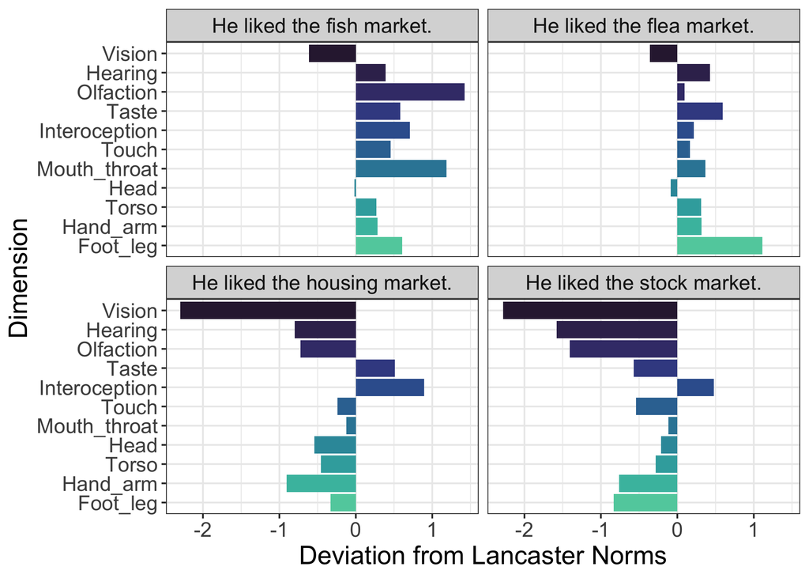

```r
df_diffs_raw <- df_dom_plus_sm %>%
  mutate(vision_diff       = (Vision.M       - Visual.mean),
         auditory_diff     = (Hearing.M      - Auditory.mean),
         intero_diff       = (Interoception.M - Interoceptive.mean),
         olfactory_diff    = (Olfaction.M    - Olfactory.mean),
         touch_diff        = (Touch.M        - Haptic.mean),
         taste_diff        = (Taste.M        - Gustatory.mean),
         torso_diff        = (Torso.M        - Torso.mean),
         hand_arm_diff     = (Hand_arm.M     - Hand_arm.mean),
         foot_leg_diff     = (Foot_leg.M     - Foot_leg.mean),
         head_diff         = (Head.M         - Head.mean),
         mouth_throat_diff = (Mouth_throat.M - Mouth.mean)) %>%
  pivot_longer(cols = ends_with("_diff"),
               names_to = "Dimension", values_to = "Diff") %>%
  mutate(Dimension = gsub('_diff', '', Dimension),
         Dimension = case_when(
           Dimension == "intero" ~ "Interoception",
           Dimension == "auditory" ~ "Hearing",
           Dimension == "olfactory" ~ "Olfaction",
           TRUE ~ str_to_title(Dimension)
         ))
df_diffs_raw$Dimension = factor(df_diffs_raw$Dimension,
                            levels = rev(c(
                              'Vision',
                              'Hearing',
                              'Olfaction',
                              'Taste',
                              'Interoception',
                              'Touch',
                              'Mouth_throat',
                              'Head',
                              'Torso',
                              'Hand_arm',
                              'Foot_leg'
                            )))






df_diffs_raw %>%
  filter(word == "market") %>%
  ggplot(aes(x = Dimension,
             y = Diff,
             fill = Dimension)) +
  geom_bar(stat = "summary") +
  geom_vline(xintercept = 0, linetype = "dotted") +
  theme_bw() +
  coord_flip() +
  labs(x = "Dimension",
       y = "Deviation from Lancaster Norms") +
  scale_fill_manual(values = viridisLite::viridis(11, option = "mako",
                                                   begin = 0.8, end = 0.15)) +
  facet_wrap(~sentence) +
  theme(text = element_text(size=16)) +
  guides(fill = FALSE)
```

```
## No summary function supplied, defaulting to `mean_se()`
## No summary function supplied, defaulting to `mean_se()`
## No summary function supplied, defaulting to `mean_se()`
## No summary function supplied, defaulting to `mean_se()`
```

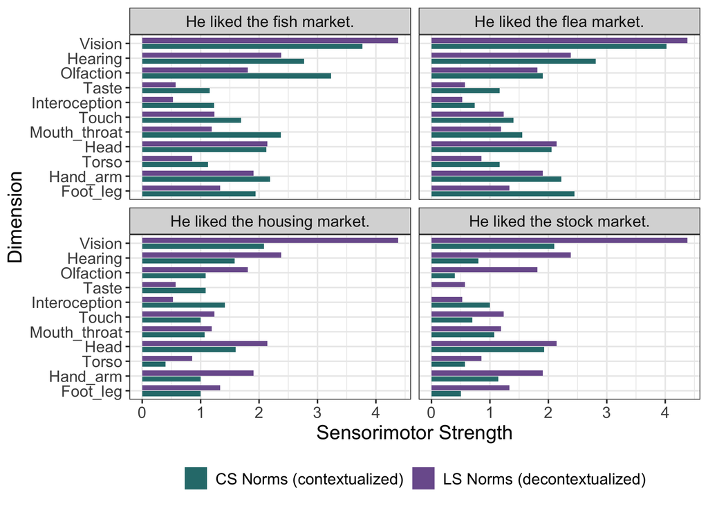

```r
df_paired_market <- df_dom_plus_sm %>%
  filter(word == "market") %>%
  select(sentence,
         Vision.M, Hearing.M, Olfaction.M, Taste.M, Interoception.M, Touch.M,
         Mouth_throat.M, Head.M, Torso.M, Hand_arm.M, Foot_leg.M,
         Visual.mean, Auditory.mean, Olfactory.mean, Gustatory.mean,
         Interoceptive.mean, Haptic.mean, Mouth.mean, Head.mean,
         Torso.mean, Hand_arm.mean, Foot_leg.mean) %>%
  pivot_longer(cols = -sentence, names_to = "raw_dim", values_to = "Rating") %>%
  mutate(
    Source = case_when(
      str_detect(raw_dim, "\\.M$") ~ "CS Norms (contextualized)",
      TRUE ~ "LS Norms (decontextualized)"
    ),
    Dimension = case_when(
      raw_dim %in% c("Vision.M", "Visual.mean") ~ "Vision",
      raw_dim %in% c("Hearing.M", "Auditory.mean") ~ "Hearing",
      raw_dim %in% c("Olfaction.M", "Olfactory.mean") ~ "Olfaction",
      raw_dim %in% c("Taste.M", "Gustatory.mean") ~ "Taste",
      raw_dim %in% c("Interoception.M", "Interoceptive.mean") ~ "Interoception",
      raw_dim %in% c("Touch.M", "Haptic.mean") ~ "Touch",
      raw_dim %in% c("Mouth_throat.M", "Mouth.mean") ~ "Mouth_throat",
      raw_dim %in% c("Head.M", "Head.mean") ~ "Head",
      raw_dim %in% c("Torso.M", "Torso.mean") ~ "Torso",
      raw_dim %in% c("Hand_arm.M", "Hand_arm.mean") ~ "Hand_arm",
      raw_dim %in% c("Foot_leg.M", "Foot_leg.mean") ~ "Foot_leg"
    )
  )

df_paired_market$Dimension <- factor(df_paired_market$Dimension,
  levels = rev(c('Vision','Hearing','Olfaction','Taste','Interoception',
                 'Touch','Mouth_throat','Head','Torso','Hand_arm','Foot_leg')))

df_paired_market %>%
  ggplot(aes(x = Dimension, y = Rating, fill = Source)) +
  geom_bar(stat = "summary", position = position_dodge(width = 0.8), width = 0.7) +
  theme_bw() +
  coord_flip() +
  labs(x = "Dimension", y = "Sensorimotor Strength", fill = NULL) +
  scale_fill_manual(values = c("CS Norms (contextualized)" = "#2c7a7b",
                               "LS Norms (decontextualized)" = "#7c5e9c")) +
  facet_wrap(~sentence) +
  theme(text = element_text(size = 14), legend.position = "bottom")
```

### Distribution of deviations

```r
df_diffs_raw %>%
  mutate(abs_diff = abs(Diff)) %>%
  summarise(mean_abs_diff = mean(abs_diff),
            median_abs_diff = median(abs_diff),
            sd_abs_diff = sd(abs_diff),
            min_abs_diff = min(abs_diff),
            max_abs_diff = max(abs_diff))
```

```
## # A tibble: 1 × 5
##   mean_abs_diff median_abs_diff sd_abs_diff min_abs_diff max_abs_diff
##           <dbl>           <dbl>       <dbl>        <dbl>        <dbl>
## 1         0.593           0.429       0.550            0         4.25
```

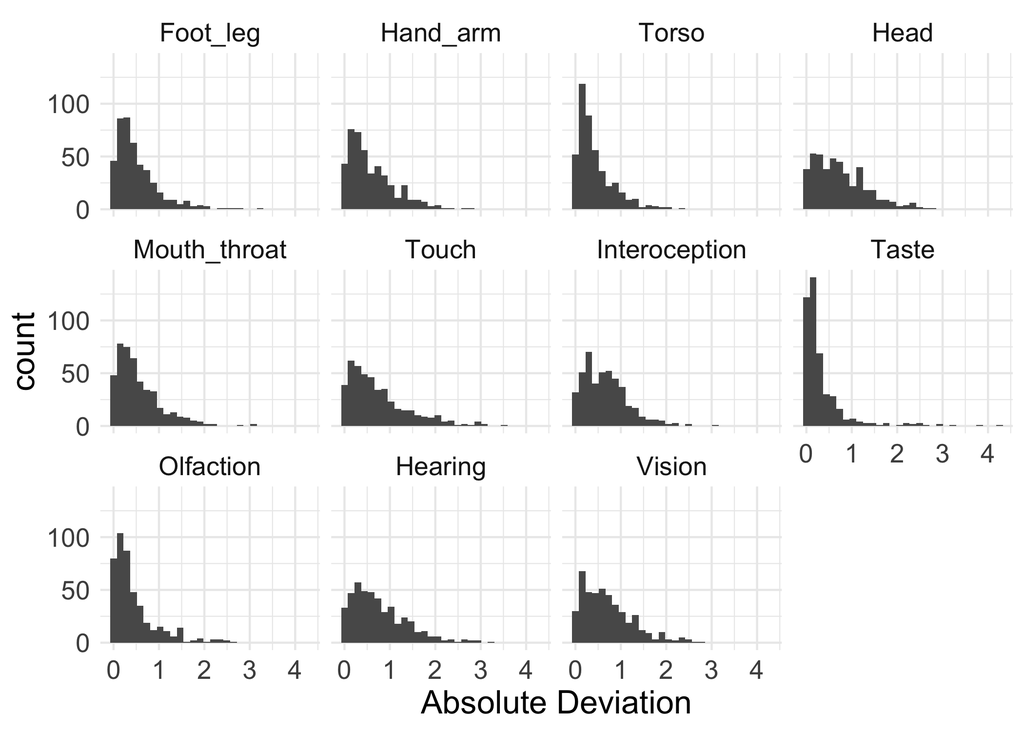

```r
df_diffs_raw %>%
  mutate(abs_diff = abs(Diff)) %>%
  ggplot(aes(x = abs_diff)) +
  geom_histogram() +
  labs(x = "Absolute Deviation") +
  theme_minimal() +
  facet_wrap(~Dimension) +
   theme(text = element_text(size=16))
```

```r
df_by_sentence_raw = df_diffs_raw %>%
  mutate(abs_diff = abs(Diff)) %>%
  group_by(word, sentence) %>%
  summarise(mean_abs_diff = mean(abs_diff),
            min_diff = min(abs_diff),
            max_diff = max(abs_diff)) %>%
  ungroup()
df_by_sentence_raw %>%
  summarise(mean_diff = mean(mean_abs_diff),
            median_abs_diff = median(mean_abs_diff),
            sd_abs_diff = sd(mean_abs_diff),
            min_abs_diff = min(mean_abs_diff),
            max_abs_diff = max(mean_abs_diff))
```

```
## # A tibble: 1 × 5
##   mean_diff median_abs_diff sd_abs_diff min_abs_diff max_abs_diff
##       <dbl>           <dbl>       <dbl>        <dbl>        <dbl>
## 1     0.593           0.550       0.216        0.225         1.60
```

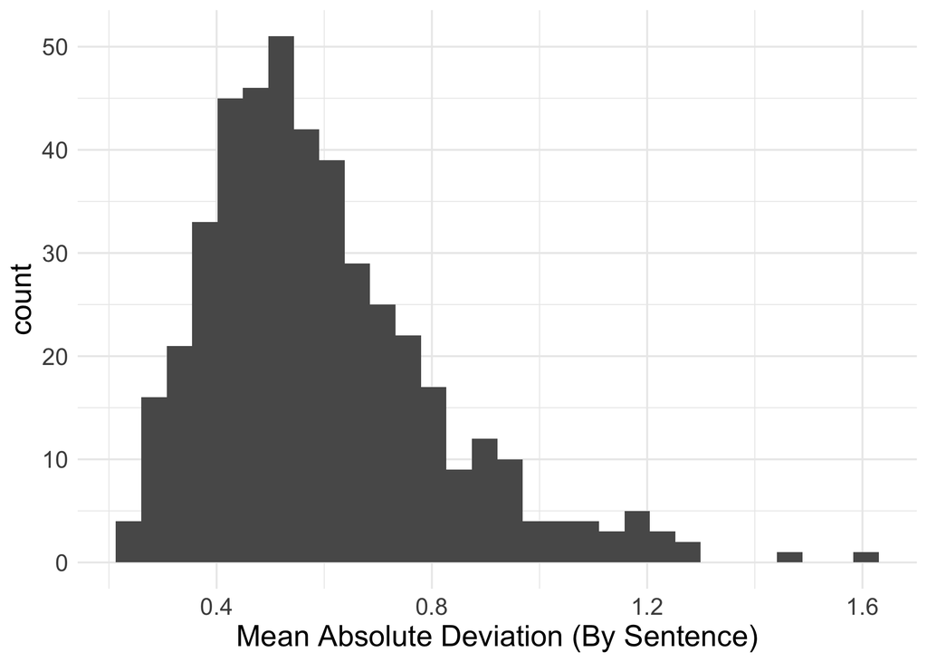

```r
df_by_sentence_raw %>%
  ggplot(aes(x = mean_abs_diff)) +
  geom_histogram() +
  labs(x = "Mean Absolute Deviation (By Sentence)") +
  theme_minimal() +
   theme(text = element_text(size=16))
```

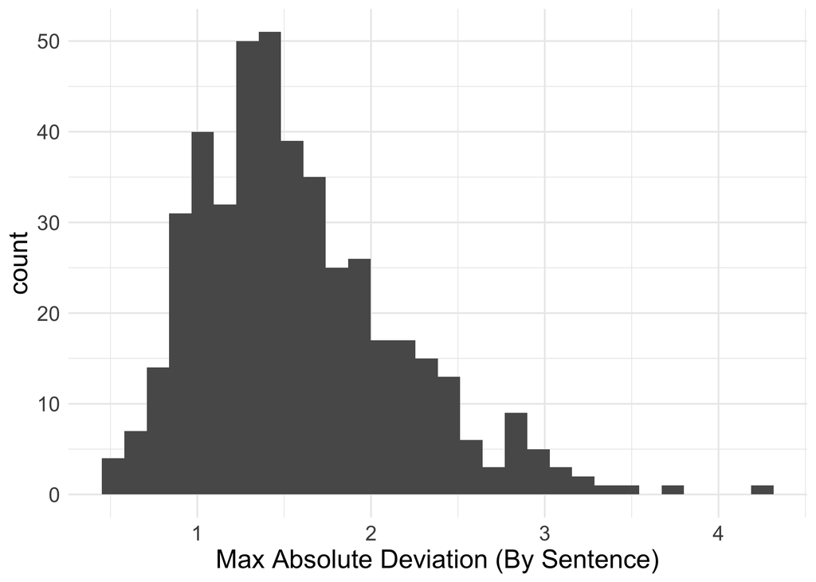

```r
df_by_sentence_raw %>%
  ggplot(aes(x = max_diff)) +
  geom_histogram() +
  labs(x = "Max Absolute Deviation (By Sentence)") +
  theme_minimal() +
   theme(text = element_text(size=16))
```

```r
df_by_sentence_raw %>%
  arrange(desc(max_diff)) %>%
  head(10)
```

```
## # A tibble: 10 × 5
##    word  sentence                    mean_abs_diff min_diff max_diff
##    <chr> <chr>                               <dbl>    <dbl>    <dbl>
##  1 jam   It was a traffic jam.               1.44   0.104       4.25
##  2 jam   It was a paper jam.                 1.20   0.226       3.76
##  3 punch He had the alcoholic punch.         1.60   0.4         3.48
##  4 load  She loaded the rifle.               0.889  0.133       3.29
##  5 match It was a soccer match.              0.951  0.0208      3.26
##  6 toast They toasted the bride.             1.13   0.0619      3.23
##  7 pen   She penned her memoirs.             0.682  0.0246      3.15
##  8 punch He had the fruit punch.             1.29   0.322       3.10
##  9 pick  He picked his scab.                 1.04   0.00929     3.05
## 10 pen   She penned her thoughts.            0.876  0.0317      3.01
```

```r
df_by_word_raw = df_diffs_raw %>%
  mutate(abs_diff = abs(Diff)) %>%
  group_by(word) %>%
  summarise(mean_abs_diff = mean(abs_diff)) %>%
  ungroup()

df_by_word_raw %>%
  summarise(mean_diff = mean(mean_abs_diff),
            median_abs_diff = median(mean_abs_diff),
            sd_abs_diff = sd(mean_abs_diff),
            min_abs_diff = min(mean_abs_diff),
            max_abs_diff = max(mean_abs_diff))
```

```
## # A tibble: 1 × 5
##   mean_diff median_abs_diff sd_abs_diff min_abs_diff max_abs_diff
##       <dbl>           <dbl>       <dbl>        <dbl>        <dbl>
## 1     0.593           0.580       0.142        0.320        0.989
```

```r
df_diffs_raw %>%
  mutate(abs_diff = abs(Diff)) %>%
  group_by(word) %>%
  summarise(mean_abs_diff = mean(abs_diff),
            sd_abs_diff = sd(abs_diff),
            range_diff = max(abs_diff) - min(abs_diff)) %>%
  arrange(desc(mean_abs_diff)) %>%
  head(5)
```

```
## # A tibble: 5 × 4
##   word  mean_abs_diff sd_abs_diff range_diff
##   <chr>         <dbl>       <dbl>      <dbl>
## 1 jam           0.989       0.943       4.20
## 2 punch         0.984       0.930       3.48
## 3 match         0.951       0.740       3.25
## 4 pen           0.934       0.911       3.13
## 5 band          0.888       0.764       2.84
```

### Individual words

```
## No summary function supplied, defaulting to `mean_se()`
## No summary function supplied, defaulting to `mean_se()`
## No summary function supplied, defaulting to `mean_se()`
## No summary function supplied, defaulting to `mean_se()`
```

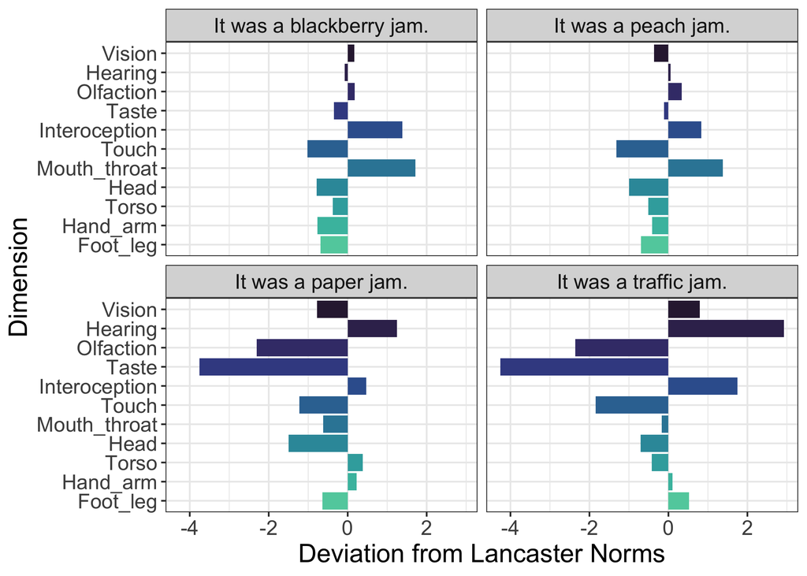

```r
df_diffs_raw = df_diffs_raw %>%
  mutate(sense = str_extract(context, "M[12]"),         # "M1" or "M2"
         context_within_sense = str_extract(context, "[ab]"))  # "a" or "b"

df_diffs_raw %>%
  filter(word == "jam") %>%
  mutate(sentence = fct_reorder(sentence, as.numeric(factor(sense)))) %>%
  ggplot(aes(x = Dimension,
             y = Diff,
             fill = Dimension)) +
  geom_bar(stat = "summary") +
  geom_vline(xintercept = 0, linetype = "dotted") +
  theme_bw() +
  coord_flip() +
  labs(x = "Dimension",
       y = "Deviation from Lancaster Norms") +
  scale_fill_manual(values = viridisLite::viridis(11, option = "mako",
                                                   begin = 0.8, end = 0.15)) +
  facet_wrap(~sentence) +
  theme(text = element_text(size=16)) +
  guides(fill = FALSE)
```

```
## No summary function supplied, defaulting to `mean_se()`
## No summary function supplied, defaulting to `mean_se()`
## No summary function supplied, defaulting to `mean_se()`
## No summary function supplied, defaulting to `mean_se()`
```

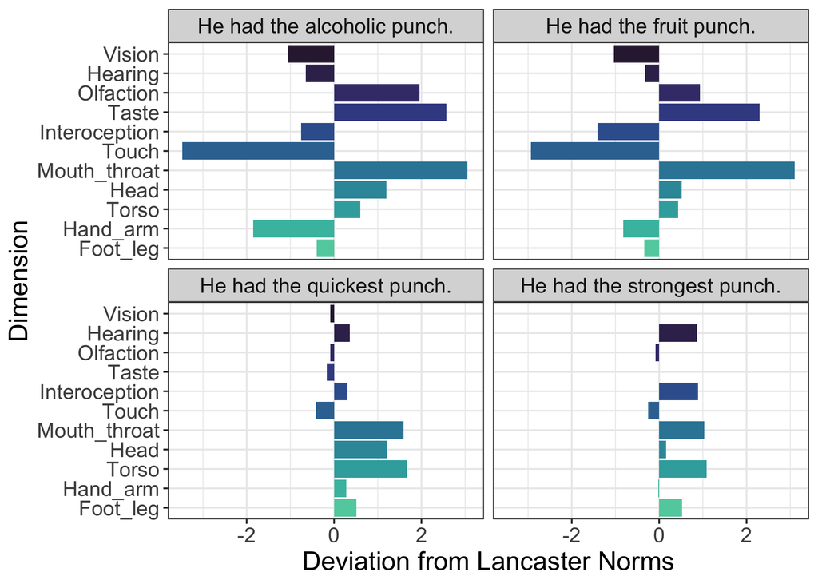

```r
df_diffs_raw %>%
  mutate(sentence = fct_reorder(sentence, as.numeric(factor(sense)))) %>%
  filter(word == "punch") %>%
  ggplot(aes(x = Dimension,
             y = Diff,
             fill = Dimension)) +
  geom_bar(stat = "summary") +
  geom_vline(xintercept = 0, linetype = "dotted") +
  theme_bw() +
  coord_flip() +
  labs(x = "Dimension",
       y = "Deviation from Lancaster Norms") +
  scale_fill_manual(values = viridisLite::viridis(11, option = "mako",
                                                   begin = 0.8, end = 0.15)) +
  facet_wrap(~sentence) +
  theme(text = element_text(size=16)) +
  guides(fill = FALSE)
```

```
## No summary function supplied, defaulting to `mean_se()`
## No summary function supplied, defaulting to `mean_se()`
## No summary function supplied, defaulting to `mean_se()`
## No summary function supplied, defaulting to `mean_se()`
```

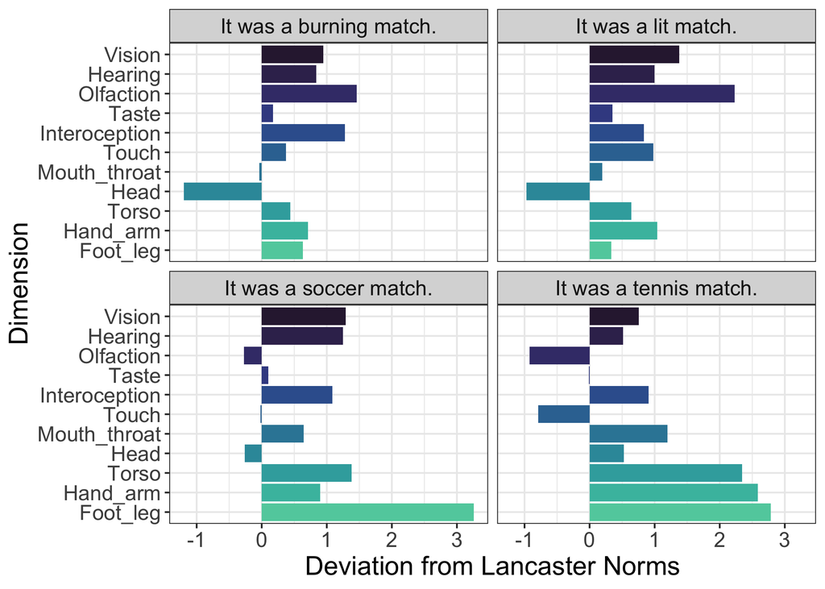

```r
df_diffs_raw %>%
  mutate(sentence = fct_reorder(sentence, as.numeric(factor(sense)))) %>%
  filter(word == "match") %>%
  ggplot(aes(x = Dimension,
             y = Diff,
             fill = Dimension)) +
  geom_bar(stat = "summary") +
  geom_vline(xintercept = 0, linetype = "dotted") +
  theme_bw() +
  coord_flip() +
  labs(x = "Dimension",
       y = "Deviation from Lancaster Norms") +
  scale_fill_manual(values = viridisLite::viridis(11, option = "mako",
                                                   begin = 0.8, end = 0.15)) +
  facet_wrap(~sentence) +
  theme(text = element_text(size=16)) +
  guides(fill = FALSE)
```

```
## No summary function supplied, defaulting to `mean_se()`
## No summary function supplied, defaulting to `mean_se()`
## No summary function supplied, defaulting to `mean_se()`
## No summary function supplied, defaulting to `mean_se()`
```

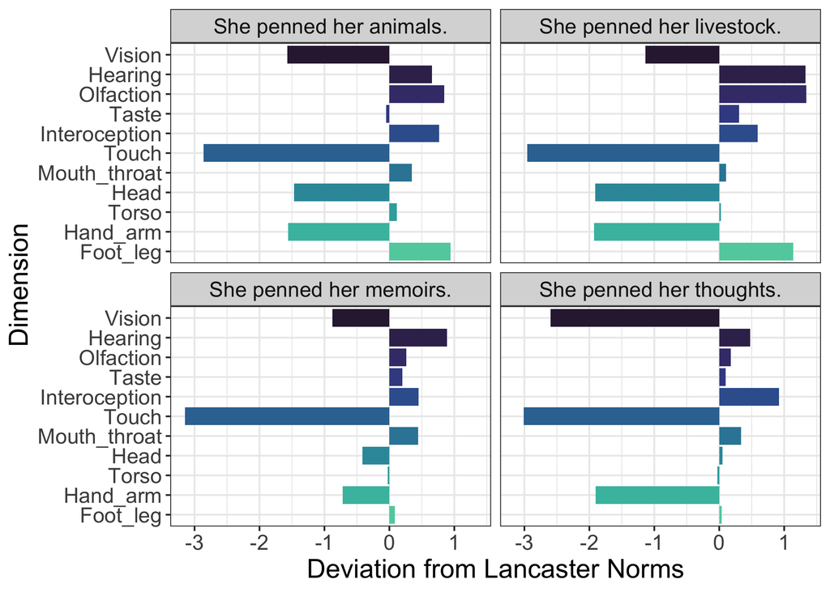

```r
df_diffs_raw %>%
  mutate(sentence = fct_reorder(sentence, as.numeric(factor(sense)))) %>%
  filter(word == "pen") %>%
  ggplot(aes(x = Dimension,
             y = Diff,
             fill = Dimension)) +
  geom_bar(stat = "summary") +
  geom_vline(xintercept = 0, linetype = "dotted") +
  theme_bw() +
  coord_flip() +
  labs(x = "Dimension",
       y = "Deviation from Lancaster Norms") +
  scale_fill_manual(values = viridisLite::viridis(11, option = "mako",
                                                   begin = 0.8, end = 0.15)) +
  facet_wrap(~sentence) +
  theme(text = element_text(size=16)) +
  guides(fill = FALSE)
```

```
## No summary function supplied, defaulting to `mean_se()`
## No summary function supplied, defaulting to `mean_se()`
## No summary function supplied, defaulting to `mean_se()`
## No summary function supplied, defaulting to `mean_se()`
```

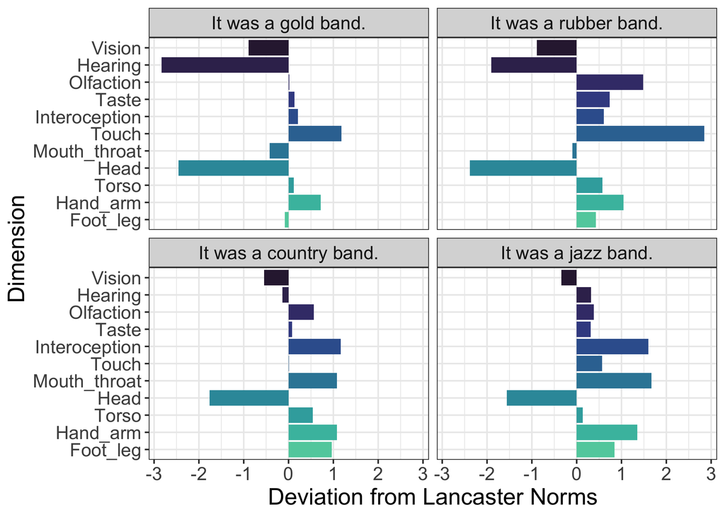

```r
df_diffs_raw %>%
  mutate(sentence = fct_reorder(sentence, as.numeric(factor(sense)))) %>%
  filter(word == "band") %>%
  ggplot(aes(x = Dimension,
             y = Diff,
             fill = Dimension)) +
  geom_bar(stat = "summary") +
  geom_vline(xintercept = 0, linetype = "dotted") +
  theme_bw() +
  coord_flip() +
  labs(x = "Dimension",
       y = "Deviation from Lancaster Norms") +
  scale_fill_manual(values = viridisLite::viridis(11, option = "mako",
                                                   begin = 0.8, end = 0.15)) +
  facet_wrap(~sentence) +
  theme(text = element_text(size=16)) +
  guides(fill = FALSE)
```

### Which dimensions have the largest deviations?

```r
df_diffs_raw %>%
  mutate(abs_diff = abs(Diff)) %>%
  group_by(Dimension) %>%
  summarise(mean_abs_diff = mean(abs_diff),
            sd_abs_diff = sd(abs_diff),
            range_diff = max(abs_diff) - min(abs_diff)) %>%
  arrange(desc(range_diff))
```

```
## # A tibble: 11 × 4
##    Dimension     mean_abs_diff sd_abs_diff range_diff
##    <fct>                 <dbl>       <dbl>      <dbl>
##  1 Taste                 0.348       0.546       4.25
##  2 Touch                 0.747       0.663       3.48
##  3 Hearing               0.765       0.603       3.29
##  4 Foot_leg              0.517       0.482       3.26
##  5 Mouth_throat          0.554       0.500       3.10
##  6 Interoception         0.667       0.489       3.05
##  7 Hand_arm              0.594       0.507       2.8
##  8 Vision                0.712       0.553       2.78
##  9 Head                  0.746       0.569       2.73
## 10 Olfaction             0.447       0.496       2.60
## 11 Torso                 0.429       0.407       2.34
```

## Z-scored deviations

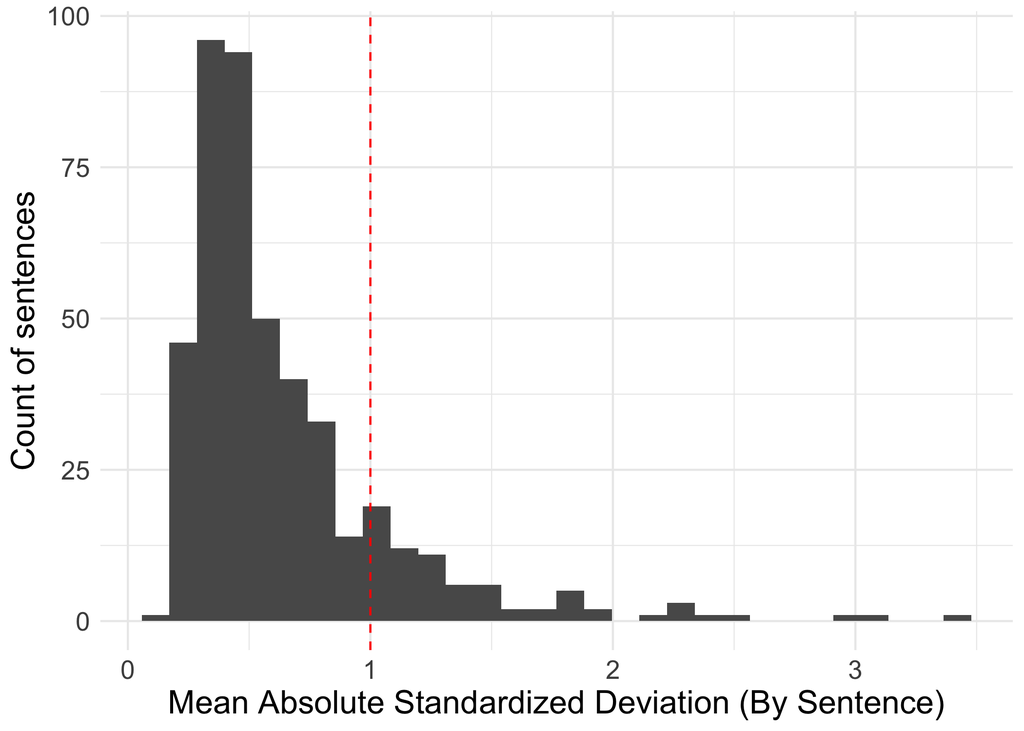

```r
SD_FLOOR <- 0.1

df_diffs_z_floored <- df_dom_plus_sm %>%
  mutate(
    vision_diff       = (Vision.M       - Visual.mean)        / pmax(Visual.SD, SD_FLOOR),
    auditory_diff     = (Hearing.M      - Auditory.mean)      / pmax(Auditory.SD, SD_FLOOR),
    intero_diff       = (Interoception.M - Interoceptive.mean) / pmax(Interoceptive.SD, SD_FLOOR),
    olfactory_diff    = (Olfaction.M    - Olfactory.mean)     / pmax(Olfactory.SD, SD_FLOOR),
    touch_diff        = (Touch.M        - Haptic.mean)        / pmax(Haptic.SD, SD_FLOOR),
    taste_diff        = (Taste.M        - Gustatory.mean)     / pmax(Gustatory.SD, SD_FLOOR),
    torso_diff        = (Torso.M        - Torso.mean)         / pmax(Torso.SD.LS, SD_FLOOR),
    hand_arm_diff     = (Hand_arm.M     - Hand_arm.mean)      / pmax(Hand_arm.SD.LS, SD_FLOOR),
    foot_leg_diff     = (Foot_leg.M     - Foot_leg.mean)      / pmax(Foot_leg.SD.LS, SD_FLOOR),
    head_diff         = (Head.M         - Head.mean)          / pmax(Head.SD.LS, SD_FLOOR),
    mouth_throat_diff = (Mouth_throat.M - Mouth.mean)         / pmax(Mouth.SD, SD_FLOOR)
  ) %>%
  pivot_longer(cols = ends_with("_diff"),
               names_to = "Dimension", values_to = "Diff") %>%
  mutate(Dimension = gsub('_diff', '', Dimension),
         Dimension = case_when(
           Dimension == "intero" ~ "Interoception",
           Dimension == "auditory" ~ "Hearing",
           Dimension == "olfactory" ~ "Olfaction",
           TRUE ~ str_to_title(Dimension)
         )) %>%
  select(word, sentence, Dimension, Diff, context, dominance)




# Distribution
sentence_dev_floored <- df_diffs_z_floored %>%
  mutate(abs_diff = abs(Diff)) %>%
  group_by(word, sentence) %>%
  summarise(mean_abs_diff = mean(abs_diff, na.rm = TRUE),
            max_abs_diff = max(abs_diff),
            .groups = "drop")

sentence_dev_floored %>%
  ggplot(aes(x = mean_abs_diff)) +
  geom_histogram(bins = 30) +
  geom_vline(xintercept = 1, linetype = "dashed", color = "red") +
  labs(x = "Mean Absolute Standardized Deviation (By Sentence)",
       y = "Count of sentences") +
  theme_minimal() +
  theme(text = element_text(size=16))
```

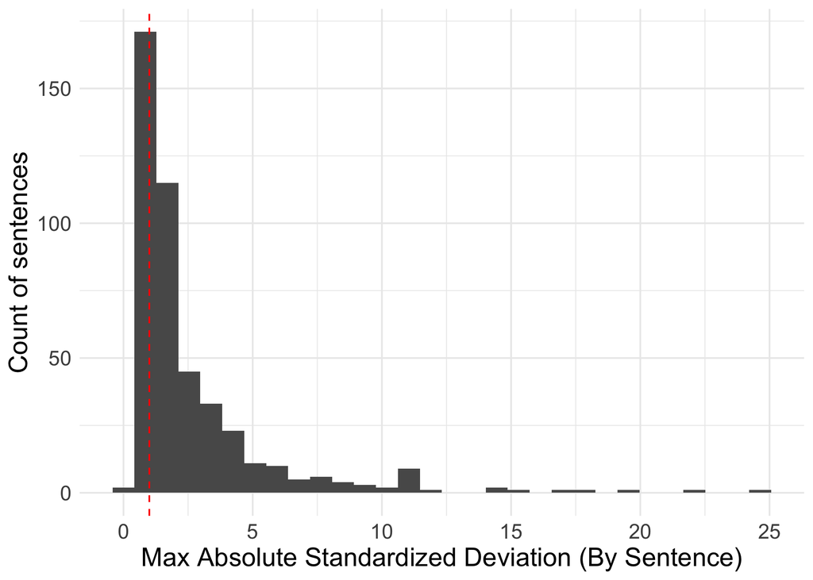

```r
sentence_dev_floored %>%
  ggplot(aes(x = max_abs_diff)) +
  geom_histogram(bins = 30) +
  geom_vline(xintercept = 1, linetype = "dashed", color = "red") +
  labs(x = "Max Absolute Standardized Deviation (By Sentence)",
       y = "Count of sentences") +
  theme_minimal() +
  theme(text = element_text(size=16))
```

```r
### Overall % sentences more than one on average
sentence_dev_floored %>%
  mutate(greater_than_one = mean_abs_diff > 1) %>%
  summarise(prop_more_than_one = mean(greater_than_one),
            max_dev = max(mean_abs_diff))
```

```
## # A tibble: 1 × 2
##   prop_more_than_one max_dev
##                <dbl>   <dbl>
## 1              0.156    3.47
```

```r
### Overall % sentences more than one maximally
quantile(sentence_dev_floored$max_abs_diff,
         probs = c(0.25, 0.5, 0.75, 0.9, 0.95, 0.99),
         na.rm = TRUE)
```

```
##       25%       50%       75%       90%       95%       99%
##  1.012154  1.551114  3.076923  5.696206  8.824150 16.135714
```

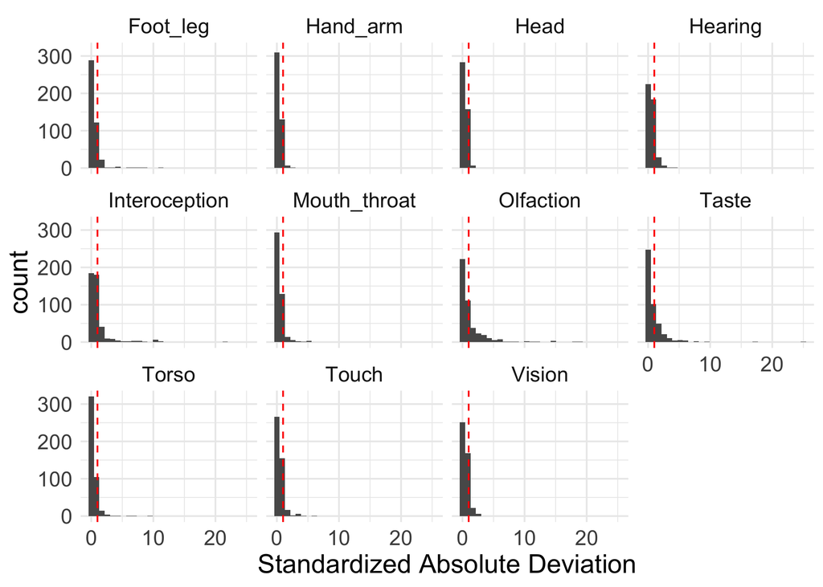

```r
### Overall deviations by dimension
df_diffs_z_floored %>%
  mutate(abs_diff = abs(Diff)) %>%
  ggplot(aes(x = abs_diff)) +
  geom_histogram() +
  labs(x = "Standardized Absolute Deviation") +
  geom_vline(xintercept = 1, linetype = "dashed", color = "red") +
  theme_minimal() +
  facet_wrap(~Dimension) +
   theme(text = element_text(size=16))
```

```r
### Overall % of contexts exceeding 1 SD
df_diffs_z_floored %>%
  mutate(abs_diff = abs(Diff)) %>%
  mutate(greater_than_one = abs_diff > 1) %>%
  summarise(prop_more_than_one = mean(greater_than_one),
            max_dev = max(abs_diff))
```

```
## # A tibble: 1 × 2
##   prop_more_than_one max_dev
##                <dbl>   <dbl>
## 1              0.142      25
```

```r
#### Additional summary statistics
df_diffs_z_floored %>%
  mutate(abs_diff = abs(Diff)) %>%
  summarise(mean_abs_diff = mean(abs_diff),
            median_abs_diff = median(abs_diff),
            sd_abs_diff = sd(abs_diff),
            min_abs_diff = min(abs_diff),
            max_abs_diff = max(abs_diff))
```

```
## # A tibble: 1 × 5
##   mean_abs_diff median_abs_diff sd_abs_diff min_abs_diff max_abs_diff
##           <dbl>           <dbl>       <dbl>        <dbl>        <dbl>
## 1         0.644           0.337        1.25            0           25
```

```r
df_by_sentence_z_floored = df_diffs_z_floored %>%
  mutate(abs_diff = abs(Diff)) %>%
  group_by(word, sentence) %>%
  summarise(mean_abs_diff = mean(abs_diff)) %>%
  ungroup()
df_by_sentence_z_floored %>%
  summarise(mean_diff = mean(mean_abs_diff),
            median_abs_diff = median(mean_abs_diff),
            sd_abs_diff = sd(mean_abs_diff),
            min_abs_diff = min(mean_abs_diff),
            max_abs_diff = max(mean_abs_diff))
```

```
## # A tibble: 1 × 5
##   mean_diff median_abs_diff sd_abs_diff min_abs_diff max_abs_diff
##       <dbl>           <dbl>       <dbl>        <dbl>        <dbl>
## 1     0.644           0.488       0.448        0.167         3.47
```

```r
df_by_word_z_floored = df_diffs_z_floored %>%
  mutate(abs_diff = abs(Diff)) %>%
  group_by(word) %>%
  summarise(mean_abs_diff = mean(abs_diff)) %>%
  ungroup()

df_by_word_z_floored %>%
  summarise(mean_diff = mean(mean_abs_diff),
            median_abs_diff = median(mean_abs_diff),
            sd_abs_diff = sd(mean_abs_diff),
            min_abs_diff = min(mean_abs_diff),
            max_abs_diff = max(mean_abs_diff))
```

```
## # A tibble: 1 × 5
##   mean_diff median_abs_diff sd_abs_diff min_abs_diff max_abs_diff
##       <dbl>           <dbl>       <dbl>        <dbl>        <dbl>
## 1     0.644           0.535       0.345        0.252         1.89
```

### Compare to raw differences

```r
# Raw (unstandardized) mean absolute deviation per sentence
sentence_dev_raw <- df_diffs_raw %>%
  mutate(abs_diff = abs(Diff)) %>%
  group_by(word, sentence, context) %>%
  summarise(mean_abs_diff = mean(abs_diff, na.rm = TRUE),
            .groups = "drop") %>%
  mutate(version = "Raw")

# Standardized (floored) mean absolute deviation per sentence
sentence_dev_z <- df_diffs_z_floored %>%
  mutate(abs_diff = abs(Diff)) %>%
  group_by(word, sentence, context) %>%
  summarise(mean_abs_diff = mean(abs_diff, na.rm = TRUE),
            .groups = "drop") %>%
  mutate(version = "Standardized")


# By sentence
sentence_compare <- sentence_dev_raw %>%
  select(word, sentence, context, raw = mean_abs_diff) %>%
  inner_join(sentence_dev_z %>%
               select(word, sentence, context, standardized = mean_abs_diff),
             by = c("word", "sentence", "context"))

cor.test(sentence_compare$raw, sentence_compare$standardized, method = "spearman")
```

```
##
##  Spearman's rank correlation rho
##
## data:  sentence_compare$raw and sentence_compare$standardized
## S = 6713942, p-value < 2.2e-16
## alternative hypothesis: true rho is not equal to 0
## sample estimates:
##       rho
## 0.5519805
```

```r
cor.test(sentence_compare$raw, sentence_compare$standardized, method = "pearson")
```

```
##
##  Pearson's product-moment correlation
##
## data:  sentence_compare$raw and sentence_compare$standardized
## t = 10.463, df = 446, p-value < 2.2e-16
## alternative hypothesis: true correlation is not equal to 0
## 95 percent confidence interval:
##  0.3663641 0.5153882
## sample estimates:
##       cor
## 0.4439407
```

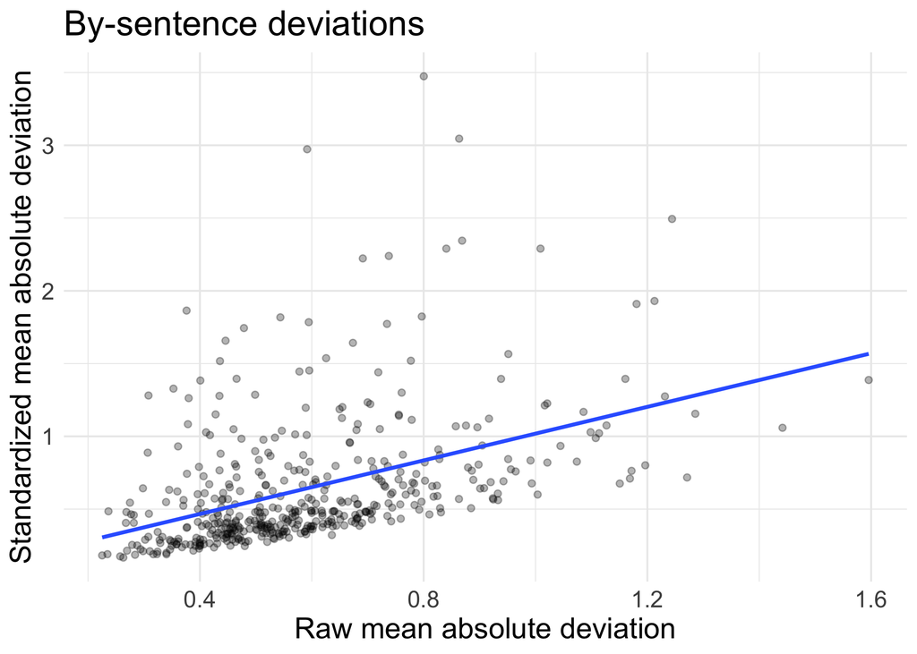

```r
sentence_compare %>%
  ggplot(aes(x = raw, y = standardized)) +
  geom_point(alpha = 0.3) +
  geom_smooth(method = "lm", se = FALSE) +
  labs(x = "Raw mean absolute deviation",
       y = "Standardized mean absolute deviation",
       title = "By-sentence deviations") +
  theme_minimal() +
  theme(text = element_text(size=16))
```

## Within-word range

Here, we calculate the *range* of sensorimotor associatoins for each dimension across the contexts of use for each word.

### Across all contexts

```r
df_rawc_with_norms = read_csv("../../data/processed/sentence_pairs_with_sensorimotor_distance.csv") %>%
  drop_na(sensorimotor_distance) %>%
  select(sensorimotor_distance, action_distance, perceptual_distance,
         word, same, ambiguity_type, sentence1, sentence2, mean_relatedness, Class, version)
nrow(df_rawc_with_norms)
```

```
## [1] 672
```

```r
word_dim_range <- df_dom_plus_sm %>%
  pivot_longer(cols = c(Vision.M, Hearing.M, Olfaction.M, Taste.M,
                        Interoception.M, Touch.M, Mouth_throat.M,
                        Head.M, Hand_arm.M, Foot_leg.M, Torso.M),
               names_to = "Dimension", values_to = "CS_value") %>%
  mutate(Dimension = gsub("\\.M$", "", Dimension)) %>%
  group_by(word, Dimension) %>%
  summarise(within_range = max(CS_value, na.rm = TRUE) - min(CS_value, na.rm = TRUE),
            .groups = "drop")

# Aggregate to word level (mean range across dimensions)
word_range <- word_dim_range %>%
  group_by(word) %>%
  summarise(mean_range = mean(within_range, na.rm = TRUE),
            max_range = max(within_range, na.rm = TRUE),
            .groups = "drop") %>%
  arrange(desc(mean_range))

print(head(word_range, 15))
```

```
## # A tibble: 15 × 3
##    word   mean_range max_range
##    <chr>       <dbl>     <dbl>
##  1 punch        1.84      3.23
##  2 jam          1.80      4.14
##  3 cell         1.69      3.13
##  4 pick         1.58      2.42
##  5 date         1.58      2.94
##  6 match        1.52      3.15
##  7 spill        1.52      2.60
##  8 racket       1.52      3.17
##  9 block        1.49      3.22
## 10 rock         1.48      3.69
## 11 lap          1.48      2.65
## 12 degree       1.43      2.28
## 13 cold         1.42      2.64
## 14 market       1.40      2.83
## 15 band         1.38      3.15
```

```r
print(tail(word_range, 15))
```

```
## # A tibble: 15 × 3
##    word         mean_range max_range
##    <chr>             <dbl>     <dbl>
##  1 cause             0.781     1.5
##  2 term              0.779     1.86
##  3 pupil             0.737     1.75
##  4 home              0.733     1.27
##  5 intelligence      0.725     1.42
##  6 stall             0.694     1.21
##  7 count             0.679     1.26
##  8 contribution      0.664     1.43
##  9 design            0.638     1.19
## 10 key               0.622     1.27
## 11 lunch             0.555     1.34
## 12 dinner            0.540     1
## 13 dream             0.537     1.02
## 14 title             0.486     1.14
## 15 guard             0.446     0.951
```

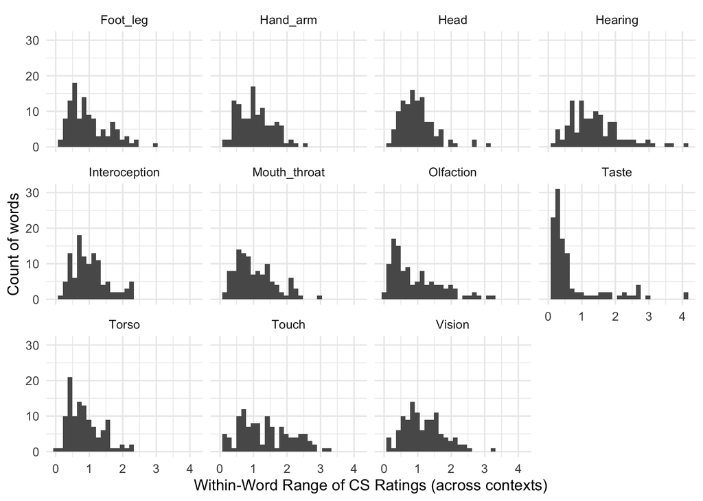

```r
# By dimension
word_dim_range %>%
  ggplot(aes(x = within_range)) +
  geom_histogram(bins = 30) +
  labs(x = "Within-Word Range of CS Ratings (across contexts)",
       y = "Count of words") +
  theme_minimal() +
  facet_wrap(~Dimension)
```

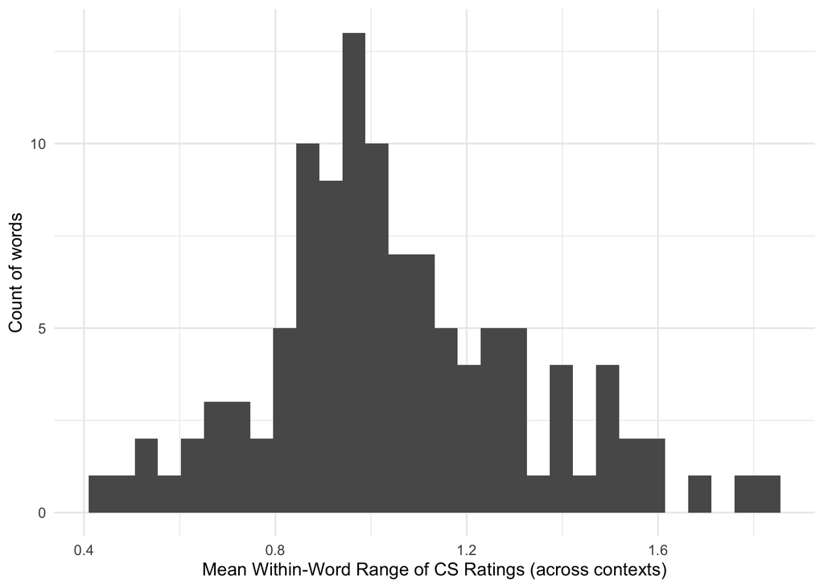

```r
# Distribution
word_range %>%
  ggplot(aes(x = mean_range)) +
  geom_histogram(bins = 30) +
  labs(x = "Mean Within-Word Range of CS Ratings (across contexts)",
       y = "Count of words") +
  theme_minimal()
```

```r
# Summary stats
word_range %>%
  summarise(mean = mean(mean_range),
            sd = sd(mean_range),
            median = median(mean_range),
            min = min(mean_range),
            max = max(mean_range))
```

```
## # A tibble: 1 × 5
##    mean    sd median   min   max
##   <dbl> <dbl>  <dbl> <dbl> <dbl>
## 1  1.05 0.272   1.01 0.446  1.84
```

```r
# Get per-word ambiguity type
word_ambiguity <- df_rawc_with_norms %>%
  distinct(word, ambiguity_type)

# Merge with within-word range
word_range_with_amb <- word_range %>%
  inner_join(word_ambiguity, by = "word")

# Summary stats by ambiguity type
word_range_with_amb %>%
  group_by(ambiguity_type) %>%
  summarise(mean = mean(mean_range),
            sd = sd(mean_range),
            median = median(mean_range),
            n = n(),
            .groups = "drop")
```

```
## # A tibble: 2 × 5
##   ambiguity_type  mean    sd median     n
##   <chr>          <dbl> <dbl>  <dbl> <int>
## 1 Homonymy        1.13 0.269  1.05     38
## 2 Polysemy        1.01 0.268  0.985    74
```

```r
# Test the difference
summary(lm(data = word_range_with_amb,
           mean_range ~ ambiguity_type))
```

```
##
## Call:
## lm(formula = mean_range ~ ambiguity_type, data = word_range_with_amb)
##
## Residuals:
##      Min       1Q   Median       3Q      Max
## -0.56678 -0.17613 -0.03526  0.13156  0.71830
##
## Coefficients:
##                        Estimate Std. Error t value Pr(>|t|)
## (Intercept)             1.12553    0.04351  25.870   <2e-16 ***
## ambiguity_typePolysemy -0.11291    0.05352  -2.109   0.0372 *
## ---
## Signif. codes:  0 '***' 0.001 '**' 0.01 '*' 0.05 '.' 0.1 ' ' 1
##
## Residual standard error: 0.2682 on 110 degrees of freedom
## Multiple R-squared:  0.03888,    Adjusted R-squared:  0.03014
## F-statistic:  4.45 on 1 and 110 DF,  p-value: 0.03717
```

```r
t.test(mean_range ~ ambiguity_type, data = word_range_with_amb)
```

```
##
##  Welch Two Sample t-test
##
## data:  mean_range by ambiguity_type
## t = 2.107, df = 74.526, p-value = 0.03848
## alternative hypothesis: true difference in means between group Homonymy and group Polysemy is not equal to 0
## 95 percent confidence interval:
##  0.006147416 0.219670747
## sample estimates:
## mean in group Homonymy mean in group Polysemy
##               1.125530               1.012621
```

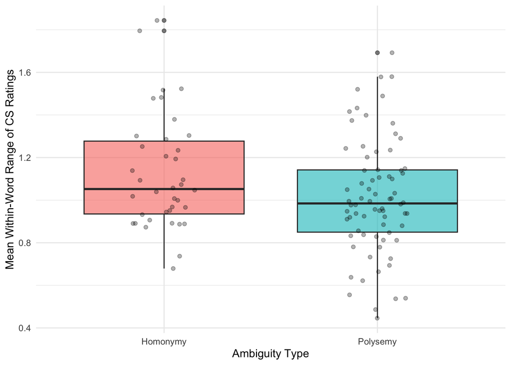

```r
# Visualize
word_range_with_amb %>%
  ggplot(aes(x = ambiguity_type, y = mean_range, fill = ambiguity_type)) +
  geom_boxplot(alpha = 0.6) +
  geom_jitter(width = 0.15, alpha = 0.3) +
  labs(x = "Ambiguity Type",
       y = "Mean Within-Word Range of CS Ratings") +
  theme_minimal() +
  theme(legend.position = "none")
```

### Between vs. Within sense

```r
# Need sense info from context column (M1/M2)
word_range_decomposed <- df_dom_plus_sm %>%
  mutate(sense = str_extract(context, "M[12]")) %>%
  pivot_longer(cols = c(Vision.M, Hearing.M, Olfaction.M, Taste.M,
                        Interoception.M, Touch.M, Mouth_throat.M,
                        Head.M, Hand_arm.M, Foot_leg.M, Torso.M),
               names_to = "Dimension", values_to = "CS_value") %>%
  mutate(Dimension = gsub("\\.M$", "", Dimension)) %>%
  group_by(word, Dimension, sense) %>%
  summarise(sense_mean = mean(CS_value),
            sense_within_range = max(CS_value) - min(CS_value),
            .groups = "drop") %>%
  group_by(word, Dimension) %>%
  summarise(between_sense_range = max(sense_mean) - min(sense_mean),
            within_sense_range = mean(sense_within_range),
            .groups = "drop") %>%
  group_by(word) %>%
  summarise(mean_between_sense = mean(between_sense_range),
            mean_within_sense = mean(within_sense_range),
            max_between_sense = max(between_sense_range),
            max_within_sense = max(within_sense_range),
            .groups = "drop")


word_range_decomposed %>%
  inner_join(word_ambiguity, by = "word") %>%
  group_by(ambiguity_type) %>%
  summarise(between = mean(mean_between_sense),
            within = mean(mean_within_sense),,
            between_max = mean(max_between_sense),
            within_max = mean(max_within_sense),
            n = n())
```

```
## # A tibble: 2 × 6
##   ambiguity_type between within between_max within_max     n
##   <chr>            <dbl>  <dbl>       <dbl>      <dbl> <int>
## 1 Homonymy         0.641  0.456        1.79      0.942    38
## 2 Polysemy         0.541  0.445        1.37      0.923    74
```

```r
# Test each separately
t.test(mean_between_sense ~ ambiguity_type,
       data = word_range_decomposed %>% inner_join(word_ambiguity, by = "word"))
```

```
##
##  Welch Two Sample t-test
##
## data:  mean_between_sense by ambiguity_type
## t = 2.0345, df = 65.538, p-value = 0.04596
## alternative hypothesis: true difference in means between group Homonymy and group Polysemy is not equal to 0
## 95 percent confidence interval:
##  0.001834152 0.196516677
## sample estimates:
## mean in group Homonymy mean in group Polysemy
##              0.6405020              0.5413266
```

```r
t.test(mean_within_sense ~ ambiguity_type,
       data = word_range_decomposed %>% inner_join(word_ambiguity, by = "word"))
```

```
##
##  Welch Two Sample t-test
##
## data:  mean_within_sense by ambiguity_type
## t = 0.53949, df = 74.952, p-value = 0.5911
## alternative hypothesis: true difference in means between group Homonymy and group Polysemy is not equal to 0
## 95 percent confidence interval:
##  -0.02992494  0.05215258
## sample estimates:
## mean in group Homonymy mean in group Polysemy
##              0.4558419              0.4447281
```

```r
# Test max
t.test(max_between_sense ~ ambiguity_type,
       data = word_range_decomposed %>% inner_join(word_ambiguity, by = "word"))
```

```
##
##  Welch Two Sample t-test
##
## data:  max_between_sense by ambiguity_type
## t = 3.1392, df = 57.366, p-value = 0.002676
## alternative hypothesis: true difference in means between group Homonymy and group Polysemy is not equal to 0
## 95 percent confidence interval:
##  0.1544563 0.6984186
## sample estimates:
## mean in group Homonymy mean in group Polysemy
##               1.793680               1.367243
```

```r
t.test(max_within_sense ~ ambiguity_type,
       data = word_range_decomposed %>% inner_join(word_ambiguity, by = "word"))
```

```
##
##  Welch Two Sample t-test
##
## data:  max_within_sense by ambiguity_type
## t = 0.35403, df = 57.851, p-value = 0.7246
## alternative hypothesis: true difference in means between group Homonymy and group Polysemy is not equal to 0
## 95 percent confidence interval:
##  -0.08810485  0.12596381
## sample estimates:
## mean in group Homonymy mean in group Polysemy
##              0.9423684              0.9234389
```

```r
word_range_decomposed_long = word_range_decomposed %>%
  inner_join(word_ambiguity, by = "word") %>%
  pivot_longer(cols = c(mean_between_sense, mean_within_sense),
               names_to = "comparison",
               values_to = "word_range")

summary(lmer(data = word_range_decomposed_long,
           word_range ~ comparison + (1|word)))
```

```
## Linear mixed model fit by REML. t-tests use Satterthwaite's method [
## lmerModLmerTest]
## Formula: word_range ~ comparison + (1 | word)
##    Data: word_range_decomposed_long
##
## REML criterion at convergence: -118
##
## Scaled residuals:
##     Min      1Q  Median      3Q     Max
## -2.0679 -0.5360 -0.0929  0.2903  4.5565
##
## Random effects:
##  Groups   Name        Variance Std.Dev.
##  word     (Intercept) 0.003939 0.06276
##  Residual             0.029268 0.17108
## Number of obs: 224, groups:  word, 112
##
## Fixed effects:
##                              Estimate Std. Error        df t value Pr(>|t|)
## (Intercept)                   0.57498    0.01722 218.91940  33.392  < 2e-16 ***
## comparisonmean_within_sense  -0.12648    0.02286 111.00000  -5.532 2.13e-07 ***
## ---
## Signif. codes:  0 '***' 0.001 '**' 0.01 '*' 0.05 '.' 0.1 ' ' 1
##
## Correlation of Fixed Effects:
##             (Intr)
## cmprsnmn_w_ -0.664
```

```r
summary(lmer(data = word_range_decomposed_long,
           word_range ~ ambiguity_type*comparison + (1|word)))
```

```
## Linear mixed model fit by REML. t-tests use Satterthwaite's method [
## lmerModLmerTest]
## Formula: word_range ~ ambiguity_type * comparison + (1 | word)
##    Data: word_range_decomposed_long
##
## REML criterion at convergence: -115.9
##
## Scaled residuals:
##     Min      1Q  Median      3Q     Max
## -2.2810 -0.5366 -0.0872  0.2989  4.2768
##
## Random effects:
##  Groups   Name        Variance Std.Dev.
##  word     (Intercept) 0.003723 0.06102
##  Residual             0.028649 0.16926
## Number of obs: 224, groups:  word, 112
##
## Fixed effects:
##                                                     Estimate Std. Error
## (Intercept)                                          0.64050    0.02919
## ambiguity_typePolysemy                              -0.09918    0.03591
## comparisonmean_within_sense                         -0.18466    0.03883
## ambiguity_typePolysemy:comparisonmean_within_sense   0.08806    0.04777
##                                                           df t value Pr(>|t|)
## (Intercept)                                        217.12757  21.945  < 2e-16
## ambiguity_typePolysemy                             217.12757  -2.762  0.00624
## comparisonmean_within_sense                        110.00000  -4.756 6.04e-06
## ambiguity_typePolysemy:comparisonmean_within_sense 110.00000   1.843  0.06796
##
## (Intercept)                                        ***
## ambiguity_typePolysemy                             **
## comparisonmean_within_sense                        ***
## ambiguity_typePolysemy:comparisonmean_within_sense .
## ---
## Signif. codes:  0 '***' 0.001 '**' 0.01 '*' 0.05 '.' 0.1 ' ' 1
##
## Correlation of Fixed Effects:
##             (Intr) ambg_P cmpr__
## ambgty_typP -0.813
## cmprsnmn_w_ -0.665  0.541
## ambgty_P:__  0.541 -0.665 -0.813
```

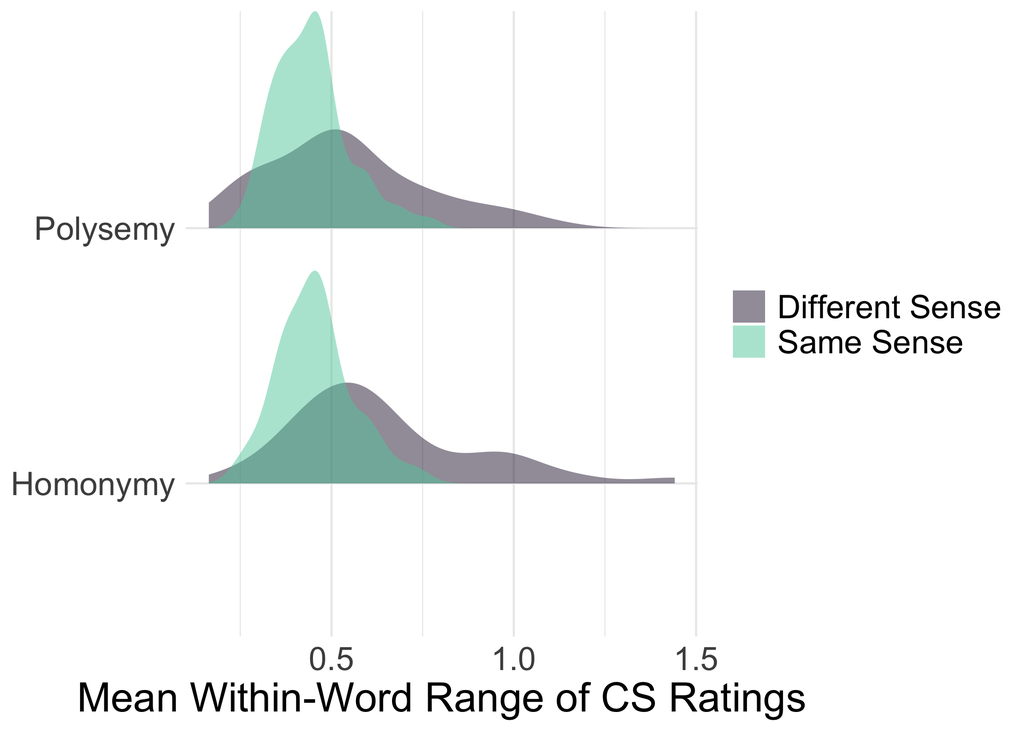

```r
word_range_decomposed_long %>%
  mutate(comparison = case_when(
    comparison == "mean_between_sense" ~ "Different Sense",
    comparison == "mean_within_sense" ~ "Same Sense"
  )) %>%
  ggplot(aes(x = word_range,
             y = ambiguity_type,
             fill = comparison)) +
  geom_density_ridges2(aes(height = ..density..),
                       color = NA,
                       alpha = 0.5,
                       scale=0.85,
                       stat="density") +
  labs(x = "Mean Within-Word Range of CS Ratings",
       y = NULL,
       fill = NULL) +
  theme_minimal() +
  scale_fill_manual(
    values = c("Same Sense" = viridisLite::viridis(2, option = "mako", begin = 0.8, end = 0.15)[1],
               "Different Sense" = viridisLite::viridis(2, option = "mako", begin = 0.8, end = 0.15)[2])
  ) +
  theme(text = element_text(size = 20))
```

```r
word_range_decomposed_long = word_range_decomposed %>%
  inner_join(word_ambiguity, by = "word") %>%
  pivot_longer(cols = c(max_between_sense, max_within_sense),
               names_to = "comparison",
               values_to = "word_range")



summary(lmer(data = word_range_decomposed_long,
           word_range ~ comparison + (1|word)))
```

```
## boundary (singular) fit: see help('isSingular')
```

```
## Linear mixed model fit by REML. t-tests use Satterthwaite's method [
## lmerModLmerTest]
## Formula: word_range ~ comparison + (1 | word)
##    Data: word_range_decomposed_long
##
## REML criterion at convergence: 319.6
##
## Scaled residuals:
##     Min      1Q  Median      3Q     Max
## -2.2928 -0.5232 -0.0806  0.4442  4.6577
##
## Random effects:
##  Groups   Name        Variance Std.Dev.
##  word     (Intercept) 0.0000   0.0000
##  Residual             0.2368   0.4866
## Number of obs: 224, groups:  word, 112
##
## Fixed effects:
##                             Estimate Std. Error        df t value Pr(>|t|)
## (Intercept)                  1.51193    0.04598 222.00000  32.884   <2e-16 ***
## comparisonmax_within_sense  -0.58207    0.06502 222.00000  -8.952   <2e-16 ***
## ---
## Signif. codes:  0 '***' 0.001 '**' 0.01 '*' 0.05 '.' 0.1 ' ' 1
##
## Correlation of Fixed Effects:
##             (Intr)
## cmprsnmx_w_ -0.707
## optimizer (nloptwrap) convergence code: 0 (OK)
## boundary (singular) fit: see help('isSingular')
```

```r
summary(lmer(data = word_range_decomposed_long,
           word_range ~ ambiguity_type*comparison + (1|word)))
```

```
## boundary (singular) fit: see help('isSingular')
```

```
## Linear mixed model fit by REML. t-tests use Satterthwaite's method [
## lmerModLmerTest]
## Formula: word_range ~ ambiguity_type * comparison + (1 | word)
##    Data: word_range_decomposed_long
##
## REML criterion at convergence: 305.2
##
## Scaled residuals:
##     Min      1Q  Median      3Q     Max
## -2.8320 -0.5416 -0.0871  0.4840  4.4578
##
## Random effects:
##  Groups   Name        Variance  Std.Dev.
##  word     (Intercept) 3.431e-20 1.852e-10
##  Residual             2.181e-01 4.670e-01
## Number of obs: 224, groups:  word, 112
##
## Fixed effects:
##                                                    Estimate Std. Error
## (Intercept)                                         1.79368    0.07576
## ambiguity_typePolysemy                             -0.42644    0.09321
## comparisonmax_within_sense                         -0.85131    0.10714
## ambiguity_typePolysemy:comparisonmax_within_sense   0.40751    0.13181
##                                                          df t value Pr(>|t|)
## (Intercept)                                       220.00000  23.675  < 2e-16
## ambiguity_typePolysemy                            220.00000  -4.575 7.95e-06
## comparisonmax_within_sense                        220.00000  -7.945 9.94e-14
## ambiguity_typePolysemy:comparisonmax_within_sense 220.00000   3.092  0.00225
##
## (Intercept)                                       ***
## ambiguity_typePolysemy                            ***
## comparisonmax_within_sense                        ***
## ambiguity_typePolysemy:comparisonmax_within_sense **
## ---
## Signif. codes:  0 '***' 0.001 '**' 0.01 '*' 0.05 '.' 0.1 ' ' 1
##
## Correlation of Fixed Effects:
##             (Intr) ambg_P cmpr__
## ambgty_typP -0.813
## cmprsnmx_w_ -0.707  0.575
## ambgty_P:__  0.575 -0.707 -0.813
## optimizer (nloptwrap) convergence code: 0 (OK)
## boundary (singular) fit: see help('isSingular')
```

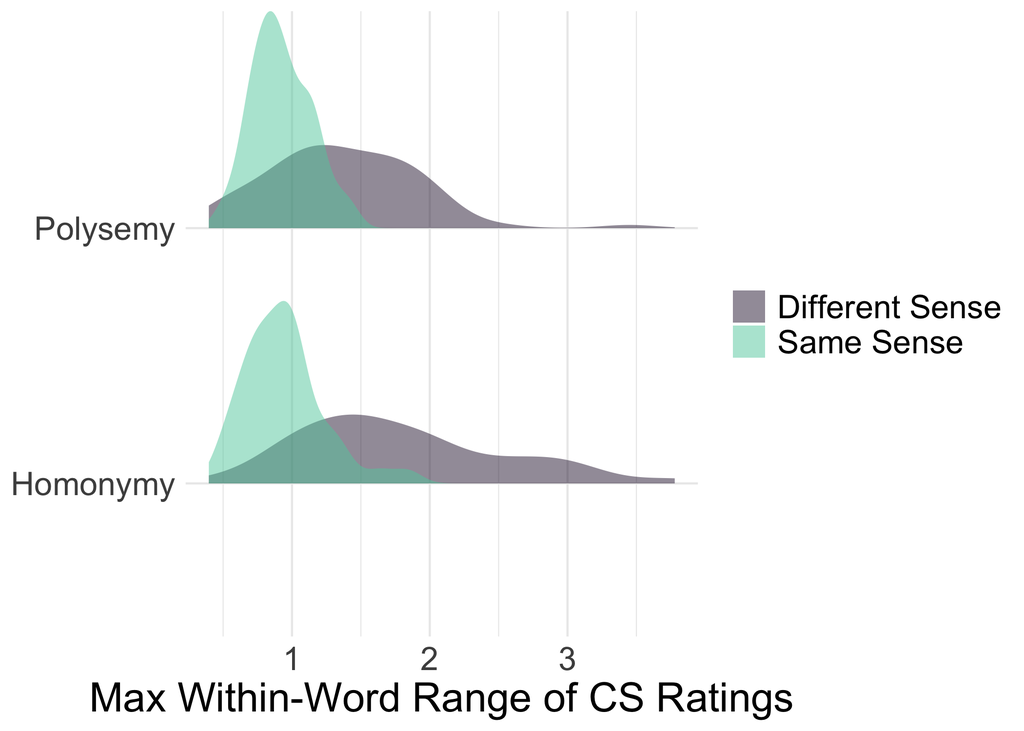

```r
word_range_decomposed_long %>%
  mutate(comparison = case_when(
    comparison == "max_between_sense" ~ "Different Sense",
    comparison == "max_within_sense" ~ "Same Sense"
  )) %>%
  ggplot(aes(x = word_range,
             y = ambiguity_type,
             fill = comparison)) +
  geom_density_ridges2(aes(height = ..density..),
                       color = NA,
                       alpha = 0.5,
                       scale=0.85,
                       stat="density") +
  labs(x = "Max Within-Word Range of CS Ratings",
       y = NULL,
       fill = NULL) +
  theme_minimal() +
  scale_fill_manual(
    values = c("Same Sense" = viridisLite::viridis(2, option = "mako", begin = 0.8, end = 0.15)[1],
               "Different Sense" = viridisLite::viridis(2, option = "mako", begin = 0.8, end = 0.15)[2])
  ) +
  theme(text = element_text(size = 20))
```

# How does dominance relate to deviation from the LS Norms?

This question can in turn be decomposed into two questions:

First, are more dominant senses **closer** to the LS Norms overall? We might expect this to be the case if the LS Norms reflect the dominant sense; that is, when people rate the sensorimotor properties of a decontextualized word, they might be more likely to index properties associated with the most dominant contexts or meanings of that word.

And the answer is **yes**: more dominant senses are indeed more *similar* (less distant) from the Lancaster norm in terms of their sensorimotor profile.

```r
model_with_dominance = lmer(data = df_dom_plus_sm,
                  distance_to_lancaster ~ dominance + (1 | word),
                  REML = FALSE)

model_no_dominance = lmer(data = df_dom_plus_sm,
                  distance_to_lancaster ~ (1 | word),
                  REML = FALSE)

summary(model_with_dominance)
```

```
## Linear mixed model fit by maximum likelihood . t-tests use Satterthwaite's
##   method [lmerModLmerTest]
## Formula: distance_to_lancaster ~ dominance + (1 | word)
##    Data: df_dom_plus_sm
##
##       AIC       BIC    logLik -2*log(L)  df.resid
##   -1305.6   -1289.2     656.8   -1313.6       444
##
## Scaled residuals:
##     Min      1Q  Median      3Q     Max
## -1.8511 -0.5791 -0.2326  0.4193  4.0935
##
## Random effects:
##  Groups   Name        Variance Std.Dev.
##  word     (Intercept) 0.000806 0.02839
##  Residual             0.002542 0.05042
## Number of obs: 448, groups:  word, 112
##
## Fixed effects:
##               Estimate Std. Error         df t value Pr(>|t|)
## (Intercept)   0.077717   0.003605 114.138534   21.56  < 2e-16 ***
## dominance    -0.009957   0.002981 344.678498   -3.34 0.000929 ***
## ---
## Signif. codes:  0 '***' 0.001 '**' 0.01 '*' 0.05 '.' 0.1 ' ' 1
##
## Correlation of Fixed Effects:
##           (Intr)
## dominance 0.099
```

```r
anova(model_with_dominance, model_no_dominance)
```

```
## Data: df_dom_plus_sm
## Models:
## model_no_dominance: distance_to_lancaster ~ (1 | word)
## model_with_dominance: distance_to_lancaster ~ dominance + (1 | word)
##                      npar     AIC     BIC logLik -2*log(L)  Chisq Df Pr(>Chisq)
## model_no_dominance      3 -1296.7 -1284.4 651.35   -1302.7
## model_with_dominance    4 -1305.6 -1289.2 656.82   -1313.6 10.934  1  0.0009444
##
## model_no_dominance
## model_with_dominance ***
## ---
## Signif. codes:  0 '***' 0.001 '**' 0.01 '*' 0.05 '.' 0.1 ' ' 1
```

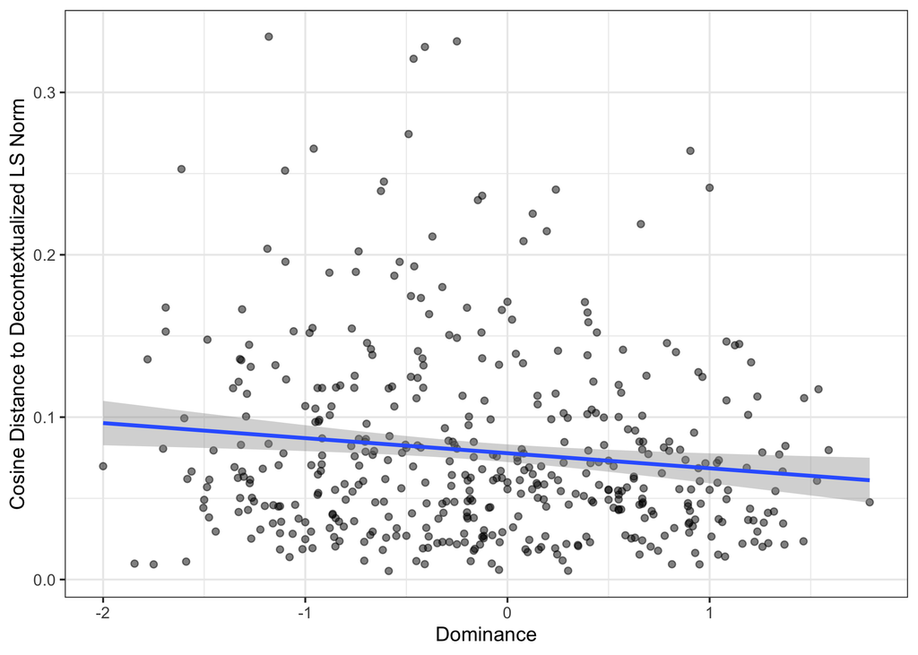

```r
df_dom_plus_sm %>%
  ggplot(aes(x = dominance,
             y = distance_to_lancaster)) +
  geom_point(alpha = .5) +
  geom_smooth(method = "lm") +
  labs(x = "Dominance",
       y = "Cosine Distance to Decontextualized LS Norm") +
  theme_bw()
```

```r
cor.test(df_dom_plus_sm$dominance, df_dom_plus_sm$distance_to_lancaster)
```

```
##
##  Pearson's product-moment correlation
##
## data:  df_dom_plus_sm$dominance and df_dom_plus_sm$distance_to_lancaster
## t = -2.7295, df = 446, p-value = 0.006594
## alternative hypothesis: true correlation is not equal to 0
## 95 percent confidence interval:
##  -0.21823310 -0.03596218
## sample estimates:
##        cor
## -0.1281799
```

And second: does dominance predict the **direction** of difference?

The earlier analysis of dominance suggests that more dominant senses are more concrete than less dominant senses. Thus, we might expect that more dominant senses are also more concrete on average than the decontextualized norms.

We find that this is true: that is, more dominant senses are *more concrete* on average than the LS norm.

```r
df_diffs_avg = df_diffs_raw %>%
  group_by(word, sentence, context) %>%
  summarise(mean_diff = mean(Diff))
df_diffs_avg = df_diffs_avg %>%
  left_join(df_dom_plus_sm)
model_with_dominance = lmer(data = df_diffs_avg,
                  mean_diff ~ dominance + (1 | word),
                  REML = FALSE)

model_no_dominance = lmer(data = df_diffs_avg,
                  mean_diff ~ (1 | word),
                  REML = FALSE)

summary(model_with_dominance)
```

```
## Linear mixed model fit by maximum likelihood . t-tests use Satterthwaite's
##   method [lmerModLmerTest]
## Formula: mean_diff ~ dominance + (1 | word)
##    Data: df_diffs_avg
##
##       AIC       BIC    logLik -2*log(L)  df.resid
##     114.1     130.5     -53.1     106.1       444
##
## Scaled residuals:
##     Min      1Q  Median      3Q     Max
## -3.8348 -0.5528 -0.0351  0.5782  2.8769
##
## Random effects:
##  Groups   Name        Variance Std.Dev.
##  word     (Intercept) 0.04174  0.2043
##  Residual             0.05175  0.2275
## Number of obs: 448, groups:  word, 112
##
## Fixed effects:
##              Estimate Std. Error        df t value Pr(>|t|)
## (Intercept) 9.659e-03  2.216e-02 1.132e+02   0.436    0.664
## dominance   8.583e-02  1.349e-02 3.407e+02   6.361 6.44e-10 ***
## ---
## Signif. codes:  0 '***' 0.001 '**' 0.01 '*' 0.05 '.' 0.1 ' ' 1
##
## Correlation of Fixed Effects:
##           (Intr)
## dominance 0.073
```

```r
anova(model_with_dominance, model_no_dominance)
```

```
## Data: df_diffs_avg
## Models:
## model_no_dominance: mean_diff ~ (1 | word)
## model_with_dominance: mean_diff ~ dominance + (1 | word)
##                      npar    AIC    BIC  logLik -2*log(L)  Chisq Df Pr(>Chisq)
## model_no_dominance      3 150.36 162.67 -72.179    144.36
## model_with_dominance    4 114.12 130.54 -53.062    106.12 38.235  1  6.271e-10
##
## model_no_dominance
## model_with_dominance ***
## ---
## Signif. codes:  0 '***' 0.001 '**' 0.01 '*' 0.05 '.' 0.1 ' ' 1
```

```r
cor.test(df_diffs_avg$dominance, df_diffs_avg$mean_diff)
```

```
##
##  Pearson's product-moment correlation
##
## data:  df_diffs_avg$dominance and df_diffs_avg$mean_diff
## t = 4.7696, df = 446, p-value = 2.504e-06
## alternative hypothesis: true correlation is not equal to 0
## 95 percent confidence interval:
##  0.1303131 0.3066838
## sample estimates:
##       cor
## 0.2202983
```

# Predicting relatedness

Next, we ask about the **sensorimotor distance** between two sentence pairs, and whether it correlates both with `same/different sense` and the `mean_relatedness` judgments for those sentence pairs.

Here, we load a version of the dataset that also contains a *baseline* measure: the sensorimotor distance as calculated using a bag-of-words approach (i.e., using the original Lancaster Norms).

## Load data

```r
df_rawc_with_norms = read_csv("../../data/processed/sentence_pairs_with_sensorimotor_distance.csv") %>%
  drop_na(sensorimotor_distance) %>%
  select(sensorimotor_distance, action_distance, perceptual_distance,
         word, same, ambiguity_type, sentence1, sentence2, mean_relatedness, Class, version)
nrow(df_rawc_with_norms)
```

```
## [1] 672
```

## Load English RAW-C data

```r
df_bert = read_csv("../../data/processed/models_english/rawc-distances_model-bert-base-uncased.csv") %>%
  mutate(Model = "BERT-base-uncased",
         Multilingual = "Monolingual")
df_bert_cased = read_csv("../../data/processed/models_english/rawc-distances_model-bert-base-cased.csv") %>%
  mutate(Model = "BERT-base-cased",
         Multilingual = "Monolingual")
df_xlm = read_csv("../../data/processed/models_english/rawc-distances_model-xlm-roberta-base.csv") %>%
  mutate(Model = "XLM-RoBERTa",
         Multilingual = "Multilingual")
df_ab1 = read_csv("../../data/processed/models_english/rawc-distances_model-albert-base-v1.csv") %>%
  mutate(Model = "ALBERT-base-v1",
         Multilingual = "Monolingual")
df_ab2 = read_csv("../../data/processed/models_english/rawc-distances_model-albert-base-v2.csv") %>%
  mutate(Model = "ALBERT-base-v2",
         Multilingual = "Monolingual")
df_al = read_csv("../../data/processed/models_english/rawc-distances_model-albert-large-v2.csv") %>%
  mutate(Model = "ALBERT-large-v2",
         Multilingual = "Monolingual")
df_axl = read_csv("../../data/processed/models_english/rawc-distances_model-albert-xlarge-v2.csv") %>%
  mutate(Model = "ALBERT-xlarge-v2",
         Multilingual = "Monolingual")
df_axxl = read_csv("../../data/processed/models_english/rawc-distances_model-albert-xxlarge-v2.csv")  %>%
  mutate(Model = "ALBERT-xxlarge-v2",
         Multilingual = "Monolingual")
df_rb = read_csv("../../data/processed/models_english/rawc-distances_model-roberta-base.csv") %>%
  mutate(Model = "RoBERTa-base",
         Multilingual = "Monolingual")
df_rl = read_csv("../../data/processed/models_english/rawc-distances_model-roberta-large.csv") %>%
  mutate(Model = "RoBERTa-large",
         Multilingual = "Monolingual")
df_db = read_csv("../../data/processed/models_english/rawc-distances_model-distilbert-base-uncased.csv") %>%
  mutate(Model = "DistilBERT",
         Multilingual = "Monolingual")
df_mb = read_csv("../../data/processed/models_english/rawc-distances_model-bert-base-multilingual-cased.csv") %>%
  mutate(Model = "Multilingual BERT",
         Multilingual = "Multilingual")
df_all = df_bert %>%
  bind_rows(df_bert_cased) %>%
  bind_rows(df_xlm) %>%
  bind_rows(df_ab1) %>%
  bind_rows(df_ab2) %>%
  bind_rows(df_al) %>%
  bind_rows(df_axl) %>%
  bind_rows(df_axxl) %>%
  bind_rows(df_rb) %>%
  bind_rows(df_rl) %>%
  bind_rows(df_db) %>%
  bind_rows(df_mb)


df_merged = df_rawc_with_norms %>%
  inner_join(df_all)
```

## Predicting same/different sense

### Sensorimotor distance and sense boundaries

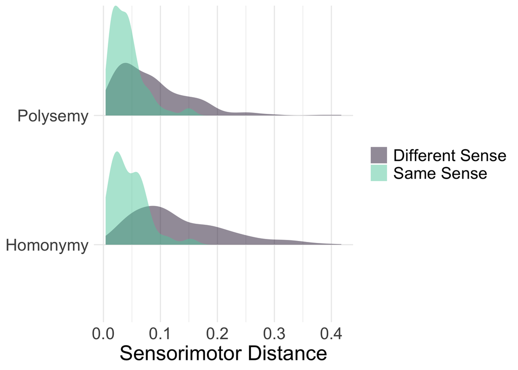

```r
df_rawc_with_norms = df_rawc_with_norms %>%
  mutate(Same = case_when(
    same == TRUE ~ "Same Sense",
    same == FALSE ~ "Different Sense"
  ))



df_rawc_with_norms %>%
  ggplot(aes(x = sensorimotor_distance,
             y = ambiguity_type,
             fill = Same)) +
  geom_density_ridges2(aes(height = ..density..),
                       color = NA,
                       alpha = 0.5,
                       scale=0.85,
                       stat="density") +
  labs(x = "Sensorimotor Distance",
       y = NULL,
       fill = NULL) +
  scale_fill_manual(
    values = c("Same Sense" = viridisLite::viridis(2, option = "mako", begin = 0.8, end = 0.15)[1],
               "Different Sense" = viridisLite::viridis(2, option = "mako", begin = 0.8, end = 0.15)[2])
  ) +
  theme_minimal() +
  theme(text = element_text(size = 20))
```

```r
model_full = lmer(data = df_rawc_with_norms,
                  sensorimotor_distance ~ same +
                    (1 + same | word),
                  control=lmerControl(optimizer="bobyqa"),
                  REML = FALSE)
```

```
## boundary (singular) fit: see help('isSingular')
```

```r
model_reduced = lmer(data = df_rawc_with_norms,
                  sensorimotor_distance ~ # same +
                    (1 + same | word),
                  control=lmerControl(optimizer="bobyqa"),
                  REML = FALSE)
```

```
## boundary (singular) fit: see help('isSingular')
```

```r
summary(model_full)
```

```
## Linear mixed model fit by maximum likelihood . t-tests use Satterthwaite's
##   method [lmerModLmerTest]
## Formula: sensorimotor_distance ~ same + (1 + same | word)
##    Data: df_rawc_with_norms
## Control: lmerControl(optimizer = "bobyqa")
##
##       AIC       BIC    logLik -2*log(L)  df.resid
##   -2203.5   -2176.4    1107.7   -2215.5       666
##
## Scaled residuals:
##     Min      1Q  Median      3Q     Max
## -3.0011 -0.5738 -0.1294  0.4572  3.7891
##
## Random effects:
##  Groups   Name        Variance Std.Dev. Corr
##  word     (Intercept) 0.003693 0.06077
##           sameTRUE    0.002874 0.05361  -1.00
##  Residual             0.001447 0.03803
## Number of obs: 672, groups:  word, 112
##
## Fixed effects:
##               Estimate Std. Error         df t value Pr(>|t|)
## (Intercept)   0.100224   0.006017 112.005213  16.658   <2e-16 ***
## sameTRUE     -0.057033   0.005946 117.316950  -9.592   <2e-16 ***
## ---
## Signif. codes:  0 '***' 0.001 '**' 0.01 '*' 0.05 '.' 0.1 ' ' 1
##
## Correlation of Fixed Effects:
##          (Intr)
## sameTRUE -0.903
## optimizer (bobyqa) convergence code: 0 (OK)
## boundary (singular) fit: see help('isSingular')
```

```r
anova(model_full, model_reduced)
```

```
## Data: df_rawc_with_norms
## Models:
## model_reduced: sensorimotor_distance ~ (1 + same | word)
## model_full: sensorimotor_distance ~ same + (1 + same | word)
##               npar     AIC     BIC logLik -2*log(L)  Chisq Df Pr(>Chisq)
## model_reduced    5 -2137.8 -2115.3 1073.9   -2147.8
## model_full       6 -2203.5 -2176.4 1107.7   -2215.5 67.654  1  < 2.2e-16 ***
## ---
## Signif. codes:  0 '***' 0.001 '**' 0.01 '*' 0.05 '.' 0.1 ' ' 1
```

```r
model_full_at = lmer(data = df_rawc_with_norms,
                  sensorimotor_distance ~ same * ambiguity_type +
                    (1 + same | word),
                  control=lmerControl(optimizer="bobyqa"),
                  REML = FALSE)
```

```
## boundary (singular) fit: see help('isSingular')
```

```r
model_reduced_at = lmer(data = df_rawc_with_norms,
                  sensorimotor_distance ~ same + ambiguity_type +
                    (1 + same | word),
                  control=lmerControl(optimizer="bobyqa"),
                  REML = FALSE)
```

```
## boundary (singular) fit: see help('isSingular')
```

```r
summary(model_full_at)
```

```
## Linear mixed model fit by maximum likelihood . t-tests use Satterthwaite's
##   method [lmerModLmerTest]
## Formula: sensorimotor_distance ~ same * ambiguity_type + (1 + same | word)
##    Data: df_rawc_with_norms
## Control: lmerControl(optimizer = "bobyqa")
##
##       AIC       BIC    logLik -2*log(L)  df.resid
##   -2212.9   -2176.8    1114.4   -2228.9       664
##
## Scaled residuals:
##     Min      1Q  Median      3Q     Max
## -2.9820 -0.5799 -0.1167  0.4644  3.8883
##
## Random effects:
##  Groups   Name        Variance Std.Dev. Corr
##  word     (Intercept) 0.003237 0.05689
##           sameTRUE    0.002490 0.04990  -1.00
##  Residual             0.001446 0.03803
## Number of obs: 672, groups:  word, 112
##
## Fixed effects:
##                                   Estimate Std. Error         df t value
## (Intercept)                       0.130023   0.009731 112.007272  13.362
## sameTRUE                         -0.084480   0.009699 118.637351  -8.710
## ambiguity_typePolysemy           -0.045101   0.011972 112.007272  -3.767
## sameTRUE:ambiguity_typePolysemy   0.041542   0.011932 118.637351   3.482
##                                 Pr(>|t|)
## (Intercept)                      < 2e-16 ***
## sameTRUE                        2.12e-14 ***
## ambiguity_typePolysemy          0.000265 ***
## sameTRUE:ambiguity_typePolysemy 0.000699 ***
## ---
## Signif. codes:  0 '***' 0.001 '**' 0.01 '*' 0.05 '.' 0.1 ' ' 1
##
## Correlation of Fixed Effects:
##             (Intr) smTRUE ambg_P
## sameTRUE    -0.892
## ambgty_typP -0.813  0.725
## smTRUE:mb_P  0.725 -0.813 -0.892
## optimizer (bobyqa) convergence code: 0 (OK)
## boundary (singular) fit: see help('isSingular')
```

```r
anova(model_full_at, model_reduced_at)
```

```
## Data: df_rawc_with_norms
## Models:
## model_reduced_at: sensorimotor_distance ~ same + ambiguity_type + (1 + same | word)
## model_full_at: sensorimotor_distance ~ same * ambiguity_type + (1 + same | word)
##                  npar     AIC     BIC logLik -2*log(L)  Chisq Df Pr(>Chisq)
## model_reduced_at    7 -2203.3 -2171.8 1108.7   -2217.3
## model_full_at       8 -2212.9 -2176.8 1114.5   -2228.9 11.539  1  0.0006816 ***
## ---
## Signif. codes:  0 '***' 0.001 '**' 0.01 '*' 0.05 '.' 0.1 ' ' 1
```

```r
df_rawc_with_norms %>%
  group_by(same, ambiguity_type) %>%
  summarise(mean = mean(sensorimotor_distance),
            sd = sd(sensorimotor_distance))
```

```
## # A tibble: 4 × 4
## # Groups:   same [2]
##   same  ambiguity_type   mean     sd
##   <lgl> <chr>           <dbl>  <dbl>
## 1 FALSE Homonymy       0.130  0.0806
## 2 FALSE Polysemy       0.0849 0.0651
## 3 TRUE  Homonymy       0.0455 0.0314
## 4 TRUE  Polysemy       0.0420 0.0297
```

### Predicting sense boundaries

Here, we run the actual analysis:

```r
model_sm_only <- glm(same ~ sensorimotor_distance,
                     data = df_rawc_with_norms,
                     family = binomial)


aic_sm_baseline <- AIC(model_sm_only)

print(paste("AIC:", round(aic_sm_baseline, 1)))
```

```
## [1] "AIC: 707.3"
```

```r
### Get aic
aic_results <- df_merged %>%
  group_by(n_params, Model, Layer) %>%
  summarize(
    # BERT only
    aic_bert = {
      model <- glm(Same_sense ~ Distance, family = binomial)
      AIC(model)
    },
    # Combined
    aic_combined = {
      model <- glm(Same_sense ~ Distance + sensorimotor_distance, family = binomial)
      AIC(model)
    },
    aic_sm = {
      model <- glm(Same_sense ~ sensorimotor_distance, family = binomial)
      AIC(model)
    },
    .groups = "drop"
  ) %>%
  mutate(
    # AIC Delta
    aic_bert_vs_sm = aic_bert - aic_sm_baseline,
    aic_combined_vs_sm = aic_sm_baseline - aic_combined,
    aic_combined_vs_dist = aic_bert - aic_combined
  )

# ============================================================
# 3. Best layer per model
# ============================================================

best_layers <- aic_results %>%
  group_by(Model, n_params) %>%
  slice_min(aic_bert, n = 1) %>%
  select(Model, Layer,
         aic_bert_vs_sm, aic_combined_vs_sm, aic_combined_vs_dist,
          aic_sm, aic_bert, aic_combined)
best_layers = best_layers %>%
  mutate(aic_bert_vs_sm2 = aic_bert - aic_sm_baseline)

print(best_layers)
```

```
## # A tibble: 12 × 10
## # Groups:   Model, n_params [12]
##     n_params Model  Layer aic_bert_vs_sm aic_combined_vs_sm aic_combined_vs_dist
##        <dbl> <chr>  <dbl>          <dbl>              <dbl>                <dbl>
##  1  11683584 ALBER…     8           29.8               80.3                110.
##  2  11683584 ALBER…    12          -80.9              144.                  62.8
##  3  17683968 ALBER…     9          -38.1              115.                  76.8
##  4  58724864 ALBER…    13         -165.               201.                  36.3
##  5 222595584 ALBER…     7         -250.               279.                  28.5
##  6 108310272 BERT-…    12         -117.               169.                  52.2
##  7 109482240 BERT-…    12         -176.               214.                  37.3
##  8  66362880 Disti…     6         -104.               153.                  49.3
##  9 177853440 Multi…     8           34.3               75.0                109.
## 10 124645632 RoBER…     8         -138.               194.                  55.9
## 11 355359744 RoBER…    16         -256.               273.                  17.1
## 12 278043648 XLM-R…     6          103.                18.3                121.
## # ℹ 4 more variables: aic_sm <dbl>, aic_bert <dbl>, aic_combined <dbl>,
## #   aic_bert_vs_sm2 <dbl>
```

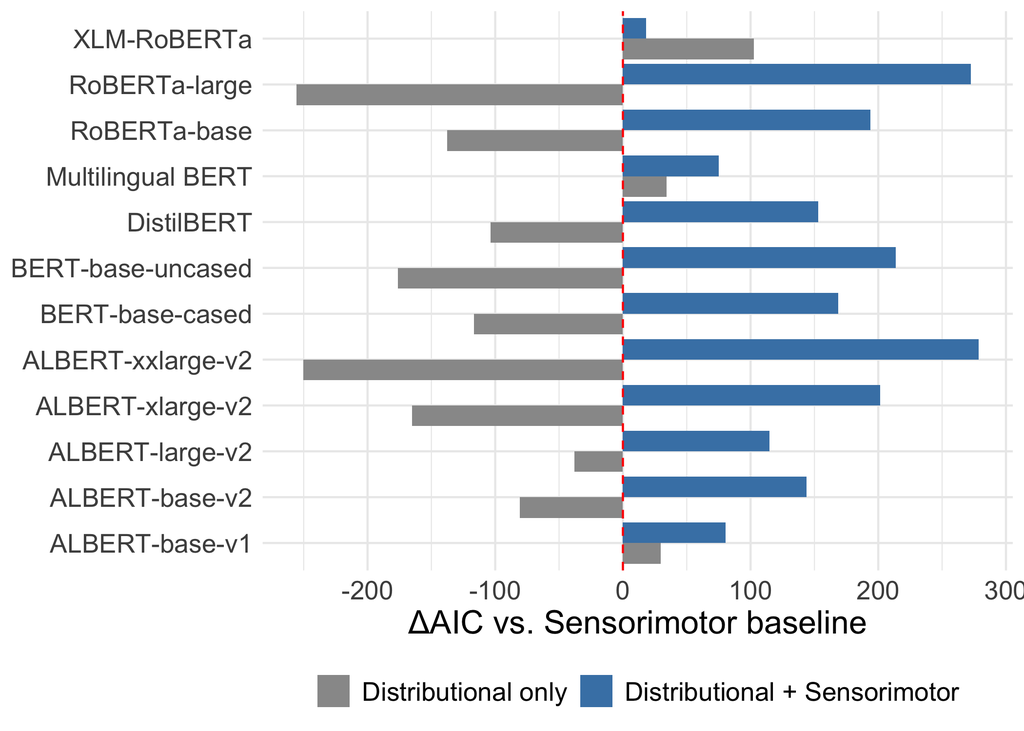

```r
## AIC difference from SM baseline

best_layers %>%
  select(Model, aic_bert_vs_sm, aic_combined_vs_sm) %>%
  pivot_longer(cols = c(aic_bert_vs_sm, aic_combined_vs_sm),
               names_to = "type", values_to = "aic_diff") %>%
  mutate(type = ifelse(type == "aic_bert_vs_sm",
                       "Distributional only",
                       "Distributional + Sensorimotor"),
         type = factor(type, levels = c("Distributional only",
                                        "Distributional + Sensorimotor")),
         Model = fct_reorder(Model, aic_diff)) %>%
  ggplot(aes(x = aic_diff, y = Model, fill = type)) +
  geom_col(position = "dodge") +
  geom_vline(xintercept = 0, linetype = "dashed", color = "red") +
  labs(x = "ΔAIC vs. Sensorimotor baseline",
       y = NULL,
       fill = NULL) +
  scale_fill_manual(values = c("Distributional only" = "gray60",
                                "Distributional + Sensorimotor" = "steelblue")) +
  theme_minimal() +
  theme(text = element_text(size = 16),
        legend.position = "bottom")
```

```r
best_layers %>%
  ungroup() %>%
  select(Model, aic_bert, aic_combined) %>%
  mutate(across(starts_with("aic"), round)) %>%
  kbl(col.names = c("Model", "Distributional", "Hybrid"),
      format = "latex",
      booktabs = TRUE,
      caption = "AIC values for predicting sense boundaries using Distributional Distance alone or both Distributional Distance and Sensorimotor Distance (AIC for Sensorimotor Distance was 707)",
      label = "aic") %>%
  kable_styling(latex_options = "hold_position")
```

```r
aic_results %>%
  mutate(dist_better_than_sm = aic_bert_vs_sm > 4,
         hybrid_better_than_sm = aic_combined_vs_sm > 4,
         hybrid_better_than_dist = aic_combined_vs_dist > 4) %>%
  summarise(mean(dist_better_than_sm),
            mean(hybrid_better_than_sm),
            mean(hybrid_better_than_dist))
```

```
## # A tibble: 1 × 3
##   `mean(dist_better_than_sm)` mean(hybrid_better_than_s…¹ mean(hybrid_better_t…²
##                         <dbl>                       <dbl>                  <dbl>
## 1                       0.414                       0.925                      1
## # ℹ abbreviated names: ¹`mean(hybrid_better_than_sm)`,
## #   ²`mean(hybrid_better_than_dist)`
```

```r
best_layers %>%
  ungroup() %>%
  mutate(dist_better_than_sm = aic_bert_vs_sm < -4,
         hybrid_better_than_sm = aic_combined_vs_sm > 4,
         hybrid_better_than_dist = aic_combined_vs_dist > 4) %>%
  summarise(mean(dist_better_than_sm),
            mean(hybrid_better_than_sm),
            mean(hybrid_better_than_dist))
```

```
## # A tibble: 1 × 3
##   `mean(dist_better_than_sm)` mean(hybrid_better_than_s…¹ mean(hybrid_better_t…²
##                         <dbl>                       <dbl>                  <dbl>
## 1                        0.75                           1                      1
## # ℹ abbreviated names: ¹`mean(hybrid_better_than_sm)`,
## #   ²`mean(hybrid_better_than_dist)`
```

```r
### Visualize raw AIC
aic_summary_full <- best_layers %>%
  select(Model, Layer, aic_sm, aic_bert, aic_combined) %>%
  pivot_longer(cols = c(aic_sm, aic_bert, aic_combined),
               names_to = "type", values_to = "aic") %>%
  mutate(type = case_when(
    type == "aic_sm" ~ "Sensorimotor",
    type == "aic_bert" ~ "Distributional",
    type == "aic_combined" ~ "Hybrid"
  ),
  type = factor(type, levels = c("Sensorimotor", "Distributional", "Hybrid")))
```

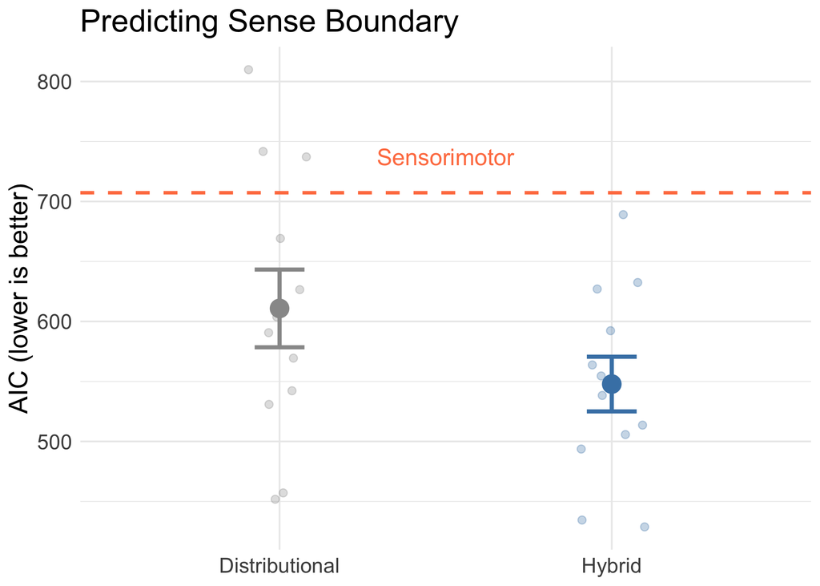

```r
# Get sensorimotor baseline (should be the same for all models)
aic_sm_baseline <- aic_summary_full %>%
  filter(type == "Sensorimotor") %>%
  pull(aic) %>%
  unique()

# Filter to just distributional and hybrid
aic_summary_no_sm <- aic_summary_full %>%
  filter(type != "Sensorimotor")

aic_summary_se_no_sm <- aic_summary_no_sm %>%
  group_by(type) %>%
  summarize(
    mean_aic = mean(aic),
    se_aic = sd(aic) / sqrt(n())
  )

ggplot() +
  # Sensorimotor baseline as dashed line
  geom_hline(yintercept = aic_sm_baseline,
             linetype = "dashed", color = "coral", linewidth = 1) +
  # Raw points for each model/layer
  geom_jitter(data = aic_summary_no_sm,
              aes(x = type, y = aic, color = type),
              alpha = 0.3, width = 0.1, size = 2) +
  # Mean + SE
  geom_point(data = aic_summary_se_no_sm,
             aes(x = type, y = mean_aic, color = type),
             size = 5) +
  geom_errorbar(data = aic_summary_se_no_sm,
                aes(x = type, ymin = mean_aic - se_aic,
                    ymax = mean_aic + se_aic, color = type),
                width = 0.15, linewidth = 1.2) +
  annotate("text", x = 1.5, y = aic_sm_baseline + 30,
           label = "Sensorimotor", color = "coral", size = 5)+
  labs(x = NULL,
       y = "AIC (lower is better)",
       title = "Predicting Sense Boundary") +
  scale_color_manual(values = c("Distributional" = "gray60",
                                "Hybrid" = "steelblue")) +
  theme_minimal() +
  theme(text = element_text(size = 16),
        legend.position = "none")
```

## Predicting relatedness

### Comparing to each distributional relatedness measure

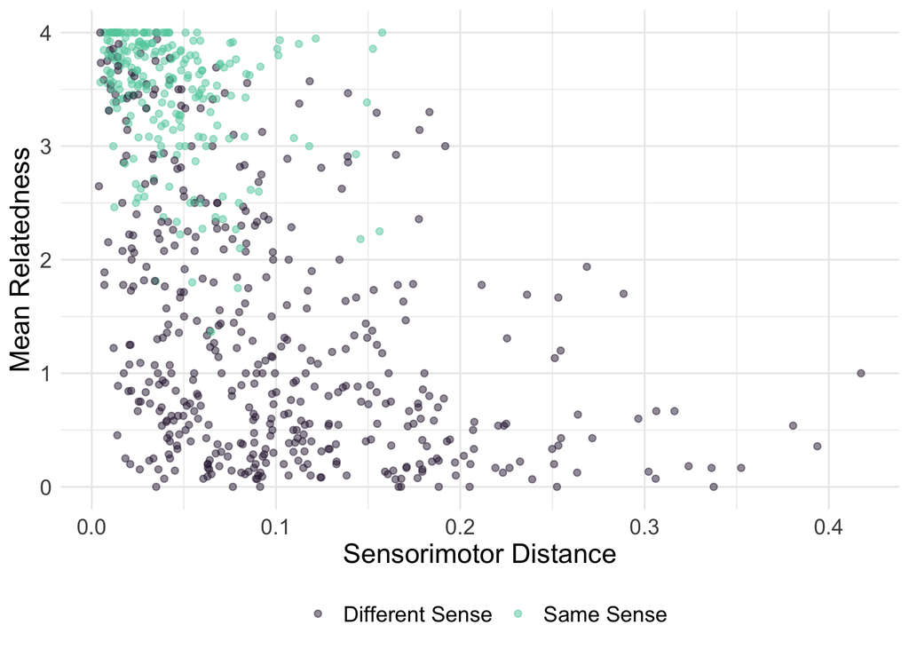

```r
df_rawc_with_norms %>%
  ggplot(aes(x = sensorimotor_distance,
            y = mean_relatedness,
            color = Same)) +
  geom_point(alpha = .5) +
  scale_color_manual(
    values = c("Same Sense" = viridisLite::viridis(2, option = "mako",
                                                   begin = 0.8, end = 0.15)[1],
               "Different Sense" = viridisLite::viridis(2, option = "mako",
                                                        begin = 0.8, end = 0.15)[2])
  ) +
  theme_minimal() +
  labs(x = "Sensorimotor Distance",
       y = "Mean Relatedness",
       color = "") +
  theme(text = element_text(size = 15),
      legend.position="bottom")
```

```r
cor(df_rawc_with_norms$sensorimotor_distance,
            df_rawc_with_norms$mean_relatedness)
```

```
## [1] -0.5346106
```